# Rectal IRST_Molinari et al Final Analysis 01232024

library(swimplot) library(grid) library(gtable) library(readr) library(mosaic) library(dplyr) library(survival) library(survminer) library(ggplot2) library(scales) library(coxphf) library(ggthemes) library(tidyverse) library(gtsummary) library(flextable) library(parameters) library(car) library(ComplexHeatmap) library(tidyverse) library(readxl) library(survival) library(janitor) library(DT) library(pROC)

#ctDNA positivity by stage and window

```r
#Number of Pts at Baseline - percentage positivity by stage
rm(list=ls())
setwd("~/Downloads")
circ_data <- read.csv("Rectal IRST_Clinical Data.csv")
circ_datadf <- as.data.frame(circ_data)

total_base <- sum(!is.na(circ_data$ctDNA.Baseline))
print(total_base)
```

```
[1] 30
```

```r
circ_data$ctDNA.Baseline <- as.factor(circ_data$ctDNA.Baseline)
cont_table_base <- table(circ_data$cStage, circ_data$ctDNA.Baseline)
print(cont_table_base)
```

```
      NEGATIVE POSITIVE
  I          0        1
  II         0        6
  III        3       20
```

```r
#Number of Pts post NAT - percentage positivity by stage
rm(list=ls())
setwd("~/Downloads")
circ_data <- read.csv("Rectal IRST_Clinical Data.csv")
circ_datadf <- as.data.frame(circ_data)

total_postnat <- sum(!is.na(circ_data$ctDNA.postNAC))
print(total_postnat)
```

```
[1] 30
```

```r
circ_data$ctDNA.postNAC <- as.factor(circ_data$ctDNA.postNAC)
cont_table_postnat <- table(circ_data$cStage, circ_data$ctDNA.postNAC)
print(cont_table_postnat)
```

```
      NEGATIVE POSITIVE
  I          1        0
  II         5        1
  III       19        4
```

```r
#Number of Pts post-surgery - percentage positivity by stage
rm(list=ls())
setwd("~/Downloads")
circ_data <- read.csv("Rectal IRST_Clinical Data.csv")
circ_datadf <- as.data.frame(circ_data)

total_mrd <- sum(!is.na(circ_data$ctDNA.postop))
print(total_mrd)
```

```
[1] 30
```

```r
circ_data$ctDNA.postop <- as.factor(circ_data$ctDNA.postop)
cont_table_mrd <- table(circ_data$cStage, circ_data$ctDNA.postop)
print(cont_table_mrd)
```

```
      NEGATIVE POSITIVE
  I          1        0
  II         5        1
  III       21        2
```

#Radiological Recurrence rates of ctDNA positive by stage and window

```r
#Number of Pts at Baseline - percentage of radiological recurrence by stage
rm(list=ls())
setwd("~/Downloads")
circ_data <- read.csv("Rectal IRST_Clinical Data.csv")
circ_data <- circ_data[circ_data$ctDNA.Baseline=="POSITIVE",]
circ_datadf <- as.data.frame(circ_data)

total_base <- sum(!is.na(circ_data$RFS.Event))
print(total_base)
```

```
[1] 27
```

```r
circ_data$RFS.Event <- as.factor(circ_data$RFS.Event)
cont_table_base <- table(circ_data$cStage, circ_data$RFS.Event)
print(cont_table_base)
```

```
      FALSE TRUE
  I       1    0
  II      5    1
  III    14    6
```

```r
#Number of Pts post NAT - percentage of radiological recurrence by stage
rm(list=ls())
setwd("~/Downloads")
circ_data <- read.csv("Rectal IRST_Clinical Data.csv")
circ_data <- circ_data[circ_data$ctDNA.postNAC=="POSITIVE",]
circ_datadf <- as.data.frame(circ_data)

total_postnat <- sum(!is.na(circ_data$RFS.Event))
print(total_postnat)
```

```
[1] 5
```

```r
circ_data$RFS.Event <- as.factor(circ_data$RFS.Event)
cont_table_postnat <- table(circ_data$cStage, circ_data$RFS.Event)
print(cont_table_postnat)
```

```
      TRUE
  II     1
  III    4
```

```r
#Number of Pts post-surgery - percentage of radiological recurrence by stage
rm(list=ls())
setwd("~/Downloads")
circ_data <- read.csv("Rectal IRST_Clinical Data.csv")
circ_data <- circ_data[circ_data$ctDNA.postop=="POSITIVE",]
circ_datadf <- as.data.frame(circ_data)

total_mrd <- sum(!is.na(circ_data$RFS.Event))
print(total_mrd)
```

```
[1] 3
```

```r
circ_data$RFS.Event <- as.factor(circ_data$RFS.Event)
cont_table_mrd <- table(circ_data$cStage, circ_data$RFS.Event)
print(cont_table_mrd)
```

```
      TRUE
  II     1
  III    2
```

#Summary Table

```r
rm(list=ls())
setwd("~/Downloads")
circ_data <- read.csv("Rectal IRST_Clinical Data.csv")
circ_datadf <- as.data.frame(circ_data)

circ_data_subset <- circ_data %>%
  select(
    Gender,
    Age,
    Height,
    Weight,
    cStage,
    cStage.TNM,
    NAT.Cycles,
    NAT.Regimen,
    Downstaging,
    postNAT.TNM,
    NAR,
    Surgery.Type,
    pStage,
    pStage.TNM,
    pN,
    pCR,
    Grade,
    MSI.status,
    Path.Response,
    ACT,
    ACT.Regimen,
    RFS.Event,
    Rec.Site,
    OS.Event,
    RFS.months,
    Total.FU.months) %>%
  mutate(
    Gender = factor(Gender, levels = c("Male", "Female")),
    Age = as.numeric(Age),
    Height = as.numeric(Height),
    Weight = as.numeric(Weight),
    cStage = factor(cStage, levels = c("I", "II", "III")),
    cStage.TNM = factor(cStage.TNM, levels = c("T2N0M0", "T2N1M0", "T3/T4N1M0", "T3N0M0", "T3N2M0", "T4N2M0")),
    NAT.Cycles = as.numeric(NAT.Cycles),
    NAT.Regimen = factor(NAT.Regimen, levels = c("FOLFOX", "Capecitabine")),
    Downstaging = factor(Downstaging, levels = c("NR", "R"), labels = c("Non Responders", "Responders")),
    postNAT.TNM = factor(postNAT.TNM, levels = c("T0N0M0", "T1/T2N0M0", "T3N0M0", "T3/T4N1M0", "T1/T2N2M0", "T3N2M0")),
    NAR = as.numeric(NAR),
    Surgery.Type = factor(Surgery.Type, levels = c("RAR", "MILES")),
    pStage = factor(pStage, levels = c("0","I", "II", "III")),
    pStage.TNM = factor(pStage.TNM, levels = c("T0N0M0", "T1/T2N0M0", "T3N0M0", "T2N1M0", "T3/T4N1M0", "T3N2M0", "T4N2M0")),
    pN = factor(pN, levels = c("0", "1", "2"), labels = c("N0", "N1", "N2")),
    pCR = factor(pCR, levels = c("TRUE", "FALSE"), labels = c("Yes", "No")),
    Grade = factor(Grade, levels = c("1", "2", "3"), labels = c("G1", "G2", "G3")),
    MSI.status = factor(MSI.status, levels = c("MSS", "MSI"), labels = c("MSS", "MSI-High")),
    Path.Response = factor(Path.Response, levels = c("Minimal Regression", "Moderate Regression", "Near Complete Regression", "Complete Regression")),
    ACT = factor(ACT, levels = c("FALSE", "TRUE"), labels = c("No adjuvant", "Adjuvant")),
    ACT.Regimen = factor(ACT.Regimen, levels = c("FOLFOX", "CAPOX", "Capecitabine")),
    RFS.Event = factor(RFS.Event, levels = c("FALSE", "TRUE"), labels = c("No Recurrence", "Recurrence")),
    Rec.Site = factor(Rec.Site, levels = c("Lung", "Lung, Liver", "Liver", "Lung, Liver, Bone", "Bone, Adrenal", "Pelvis")),
    OS.Event = factor(OS.Event, levels = c("FALSE", "TRUE"), labels = c("Alive", "Deceased")),
    RFS.months = as.numeric(RFS.months),
    Total.FU.months = as.numeric(Total.FU.months))
table1 <- circ_data_subset %>%
  tbl_summary(
    statistic = list(
      all_continuous() ~ "{median} ({min} - {max})",
      all_categorical() ~ "{n} ({p}%)")) %>%
  bold_labels()
table1
```

| **Characteristic** | **N = 30**<sup>1</sup> |
| --- | --- |
| Gender |  |
| Male | 21 (70%) |
| Female | 9 (30%) |
| Age | 67 (38 - 80) |
| Height | 173 (120 - 184) |
| Weight | 72 (38 - 120) |
| cStage |  |
| I | 1 (3.3%) |
| II | 6 (20%) |
| III | 23 (77%) |
| cStage.TNM |  |
| T2N0M0 | 1 (3.3%) |
| T2N1M0 | 3 (10%) |
| T3/T4N1M0 | 13 (43%) |
| T3N0M0 | 6 (20%) |
| T3N2M0 | 4 (13%) |
| T4N2M0 | 3 (10%) |
| NAT.Cycles |  |
| 3 | 1 (3.3%) |
| 4 | 12 (40%) |
| 5 | 4 (13%) |
| 6 | 12 (40%) |
| 7 | 1 (3.3%) |
| NAT.Regimen |  |
| FOLFOX | 13 (43%) |
| Capecitabine | 17 (57%) |
| Downstaging |  |
| Non Responders | 5 (17%) |
| Responders | 25 (83%) |
| postNAT.TNM |  |

[output cut: 74 more lines]

<sup>1</sup> n (%); Median (Range)

```r
fit1 <- as_flex_table(
  table1,
  include = everything(),
  return_calls = FALSE,
  strip_md_bold = TRUE)
fit1
```

| Characteristic | N = 301 |
| --- | --- |
| Gender |  |
| Male | 21 (70%) |
| Female | 9 (30%) |
| Age | 67 (38 - 80) |
| Height | 173 (120 - 184) |
| Weight | 72 (38 - 120) |
| cStage |  |
| I | 1 (3.3%) |
| II | 6 (20%) |
| III | 23 (77%) |
| cStage.TNM |  |
| T2N0M0 | 1 (3.3%) |
| T2N1M0 | 3 (10%) |
| T3/T4N1M0 | 13 (43%) |
| T3N0M0 | 6 (20%) |
| T3N2M0 | 4 (13%) |
| T4N2M0 | 3 (10%) |
| NAT.Cycles |  |
| 3 | 1 (3.3%) |
| 4 | 12 (40%) |
| 5 | 4 (13%) |
| 6 | 12 (40%) |
| 7 | 1 (3.3%) |
| NAT.Regimen |  |
| FOLFOX | 13 (43%) |
| Capecitabine | 17 (57%) |
| Downstaging |  |
| Non Responders | 5 (17%) |
| Responders | 25 (83%) |
| postNAT.TNM |  |

[output cut: 74 more lines]

1n (%); Median (Range)

```r
save_as_docx(fit1, path= "~/Downloads/table1.docx")
```

#Summary Table with IQR

```r
rm(list=ls())
setwd("~/Downloads")
circ_data <- read.csv("Rectal IRST_Clinical Data.csv")
circ_datadf <- as.data.frame(circ_data)

circ_data_subset <- circ_data %>%
  select(
    Gender,
    Age,
    Height,
    Weight,
    cStage,
    cStage.TNM,
    NAT.Cycles,
    NAT.Regimen,
    Downstaging,
    postNAT.TNM,
    NAR,
    Surgery.Type,
    pStage,
    pStage.TNM,
    pN,
    pCR,
    Grade,
    MSI.status,
    Path.Response,
    ACT,
    ACT.Regimen,
    RFS.Event,
    Rec.Site,
    OS.Event,
    RFS.months,
    Total.FU.months) %>%
  mutate(
    Gender = factor(Gender, levels = c("Male", "Female")),
    Age = as.numeric(Age),
    Height = as.numeric(Height),
    Weight = as.numeric(Weight),
    cStage = factor(cStage, levels = c("I", "II", "III")),
    cStage.TNM = factor(cStage.TNM, levels = c("T2N0M0", "T2N1M0", "T3/T4N1M0", "T3N0M0", "T3N2M0", "T4N2M0")),
    NAT.Cycles = as.numeric(NAT.Cycles),
    NAT.Regimen = factor(NAT.Regimen, levels = c("FOLFOX", "Capecitabine")),
    Downstaging = factor(Downstaging, levels = c("NR", "R"), labels = c("Non Responders", "Responders")),
    postNAT.TNM = factor(postNAT.TNM, levels = c("T0N0M0", "T1/T2N0M0", "T3N0M0", "T3/T4N1M0", "T1/T2N2M0", "T3N2M0")),
    NAR = as.numeric(NAR),
    Surgery.Type = factor(Surgery.Type, levels = c("RAR", "MILES")),
    pStage = factor(pStage, levels = c("0","I", "II", "III")),
    pStage.TNM = factor(pStage.TNM, levels = c("T0N0M0", "T1/T2N0M0", "T3N0M0", "T2N1M0", "T3/T4N1M0", "T3N2M0", "T4N2M0")),
    pN = factor(pN, levels = c("0", "1", "2"), labels = c("N0", "N1", "N2")),
    pCR = factor(pCR, levels = c("TRUE", "FALSE"), labels = c("Yes", "No")),
    Grade = factor(Grade, levels = c("1", "2", "3"), labels = c("G1", "G2", "G3")),
    MSI.status = factor(MSI.status, levels = c("MSS", "MSI"), labels = c("MSS", "MSI-High")),
    Path.Response = factor(Path.Response, levels = c("Minimal Regression", "Moderate Regression", "Near Complete Regression", "Complete Regression")),
    ACT = factor(ACT, levels = c("FALSE", "TRUE"), labels = c("No adjuvant", "Adjuvant")),
    ACT.Regimen = factor(ACT.Regimen, levels = c("FOLFOX", "CAPOX", "Capecitabine")),
    RFS.Event = factor(RFS.Event, levels = c("FALSE", "TRUE"), labels = c("No Recurrence", "Recurrence")),
    Rec.Site = factor(Rec.Site, levels = c("Lung", "Lung, Liver", "Liver", "Lung, Liver, Bone", "Bone, Adrenal", "Pelvis")),
    OS.Event = factor(OS.Event, levels = c("FALSE", "TRUE"), labels = c("Alive", "Deceased")),
    RFS.months = as.numeric(RFS.months),
    Total.FU.months = as.numeric(Total.FU.months))
table1 <- circ_data_subset %>%
  tbl_summary(
    statistic = list(
      all_continuous() ~ "{median} ({p25}, {p75})",
      all_categorical() ~ "{n} ({p}%)")) %>%
  bold_labels()
table1
```

| **Characteristic** | **N = 30**<sup>1</sup> |
| --- | --- |
| Gender |  |
| Male | 21 (70%) |
| Female | 9 (30%) |
| Age | 67 (63, 76) |
| Height | 173 (161, 178) |
| Weight | 72 (59, 89) |
| cStage |  |
| I | 1 (3.3%) |
| II | 6 (20%) |
| III | 23 (77%) |
| cStage.TNM |  |
| T2N0M0 | 1 (3.3%) |
| T2N1M0 | 3 (10%) |
| T3/T4N1M0 | 13 (43%) |
| T3N0M0 | 6 (20%) |
| T3N2M0 | 4 (13%) |
| T4N2M0 | 3 (10%) |
| NAT.Cycles |  |
| 3 | 1 (3.3%) |
| 4 | 12 (40%) |
| 5 | 4 (13%) |
| 6 | 12 (40%) |
| 7 | 1 (3.3%) |
| NAT.Regimen |  |
| FOLFOX | 13 (43%) |
| Capecitabine | 17 (57%) |
| Downstaging |  |
| Non Responders | 5 (17%) |
| Responders | 25 (83%) |
| postNAT.TNM |  |

[output cut: 74 more lines]

<sup>1</sup> n (%); Median (IQR)

```r
fit1 <- as_flex_table(
  table1,
  include = everything(),
  return_calls = FALSE,
  strip_md_bold = TRUE)
fit1
```

| Characteristic | N = 301 |
| --- | --- |
| Gender |  |
| Male | 21 (70%) |
| Female | 9 (30%) |
| Age | 67 (63, 76) |
| Height | 173 (161, 178) |
| Weight | 72 (59, 89) |
| cStage |  |
| I | 1 (3.3%) |
| II | 6 (20%) |
| III | 23 (77%) |
| cStage.TNM |  |
| T2N0M0 | 1 (3.3%) |
| T2N1M0 | 3 (10%) |
| T3/T4N1M0 | 13 (43%) |
| T3N0M0 | 6 (20%) |
| T3N2M0 | 4 (13%) |
| T4N2M0 | 3 (10%) |
| NAT.Cycles |  |
| 3 | 1 (3.3%) |
| 4 | 12 (40%) |
| 5 | 4 (13%) |
| 6 | 12 (40%) |
| 7 | 1 (3.3%) |
| NAT.Regimen |  |
| FOLFOX | 13 (43%) |
| Capecitabine | 17 (57%) |
| Downstaging |  |
| Non Responders | 5 (17%) |
| Responders | 25 (83%) |
| postNAT.TNM |  |

[output cut: 74 more lines]

1n (%); Median (IQR)

```r
save_as_docx(fit1, path= "~/Downloads/table1.docx")
```

#DFS in Complete Cohort

```r
rm(list=ls())
setwd("~/Downloads")
circ_data <- read.csv("Rectal IRST_Clinical Data.csv")
circ_datadf <- as.data.frame(circ_data)

survfit(Surv(time = circ_data$DFS.months, event = circ_data$DFS.Event)~Rectal.Rome, data = circ_data)
```

```
Call: survfit(formula = Surv(time = circ_data$DFS.months, event = circ_data$DFS.Event) ~
    Rectal.Rome, data = circ_data)

   3 observations deleted due to missingness
      n events median 0.95LCL 0.95UCL
[1,] 30     12     NA    62.7      NA
```

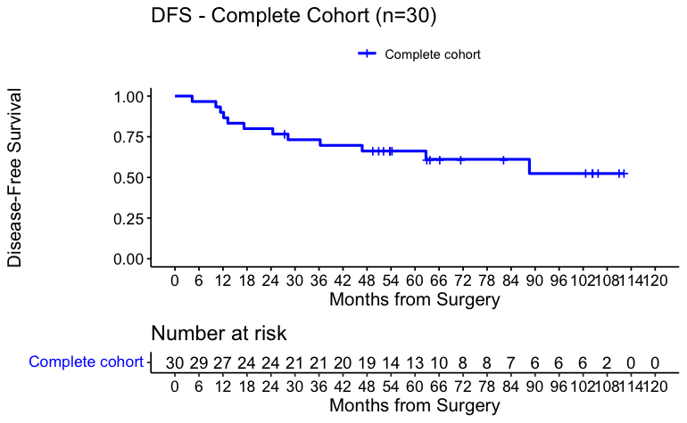

```r
surv_object <-Surv(time = circ_data$DFS.months, event = circ_data$DFS.Event)
KM_curve <- survfit(surv_object ~ Rectal.Rome, data = circ_data,conf.int=0.95,conf.type="log-log")
ggsurvplot(KM_curve, data = circ_data, pval = FALSE, conf.int = FALSE, risk.table = TRUE, break.time.by=6, palette=c("blue"), title="DFS - Complete Cohort (n=30)", ylab= "Disease-Free Survival", xlab="Months from Surgery", legend.labs=c("Complete cohort"), legend.title="")
```

```r
summary(KM_curve, times= c(18, 24, 36))
```

```
Call: survfit(formula = surv_object ~ Rectal.Rome, data = circ_data,
    conf.int = 0.95, conf.type = "log-log")

3 observations deleted due to missingness
 time n.risk n.event survival std.err lower 95% CI upper 95% CI
   18     24       6    0.800  0.0730        0.608        0.905
   24     24       0    0.800  0.0730        0.608        0.905
   36     21       2    0.732  0.0812        0.534        0.856
```

#Total Follow-up in Complete Cohort

```r
rm(list=ls())
setwd("~/Downloads")
circ_data <- read.csv("Rectal IRST_Clinical Data.csv")
circ_datadf <- as.data.frame(circ_data)

survfit(Surv(time = circ_data$Total.FU.months, event = circ_data$OS.Event)~Rectal.Rome, data = circ_data)
```

```
Call: survfit(formula = Surv(time = circ_data$Total.FU.months, event = circ_data$OS.Event) ~
    Rectal.Rome, data = circ_data)

   3 observations deleted due to missingness
      n events median 0.95LCL 0.95UCL
[1,] 30     10     NA    92.7      NA
```

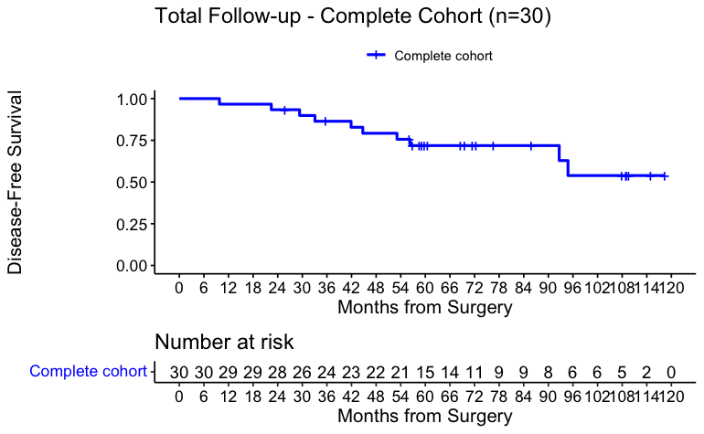

```r
surv_object <-Surv(time = circ_data$Total.FU.months, event = circ_data$OS.Event)
KM_curve <- survfit(surv_object ~ Rectal.Rome, data = circ_data,conf.int=0.95,conf.type="log-log")
ggsurvplot(KM_curve, data = circ_data, pval = FALSE, conf.int = FALSE, risk.table = TRUE, break.time.by=6, palette=c("blue"), title="Total Follow-up - Complete Cohort (n=30)", ylab= "Disease-Free Survival", xlab="Months from Surgery", legend.labs=c("Complete cohort"), legend.title="")
```

```r
summary(KM_curve, times= c(18, 24, 36))
```

```
Call: survfit(formula = surv_object ~ Rectal.Rome, data = circ_data,
    conf.int = 0.95, conf.type = "log-log")

3 observations deleted due to missingness
 time n.risk n.event survival std.err lower 95% CI upper 95% CI
   18     29       1    0.967  0.0328        0.786        0.995
   24     28       1    0.933  0.0455        0.759        0.983
   36     24       2    0.864  0.0632        0.677        0.947
```

#Heatmap for the clinical factors

```r
rm(list=ls())
setwd("~/Downloads")
circ_data <- read.csv("Rectal IRST_Clinical Data.csv")
circ_datadf <- as.data.frame(circ_data)
circ_data <- circ_data %>% arrange(cStage)
circ_datadf <- as.data.frame(circ_data)

ha <- HeatmapAnnotation(
  cStage = circ_data$cStage,
  Gender = circ_data$Gender,
  NAT.Regimen = circ_data$NAT.Regimen,
  Downstaging = circ_data$Downstaging,
  NAR.Score = circ_data$NAR.Score,
  pStage = circ_data$pStage,
  Grade = circ_data$Grade,
  ACT = circ_data$ACT,
  ACT.Regimen = circ_data$ACT.Regimen,
  ctDNA.Baseline = circ_data$ctDNA.Baseline,
  ctDNA.postNAC = circ_data$ctDNA.postNAC,
  ctDNA.postop = circ_data$ctDNA.postop,
  ctDNA.anytime = circ_data$ctDNA.anytime,
  RFS.Event = circ_data$RFS.Event,
  OS.Event = circ_data$OS.Event,

    col = list(cStage = c("I" = "seagreen1", "II" = "khaki", "III" = "orange"),
    Gender = c("Female" = "goldenrod" , "Male" = "blue4"),
    NAT.Regimen = c("FOLFOX" = "coral", "Capecitabine" ="darkgreen"),
    Downstaging = c("R" = "yellow", "NR" ="brown"),
    NAR.Score = c("Low" = "lightblue", "Mid/High" ="orange"),
    pStage = c("0" = "khaki","I" = "seagreen2", "II" = "cornflowerblue", "III" ="darkmagenta"),
    Grade = c("1" = "yellow3", "2" ="darkgreen", "3" = "brown2"),
    ACT = c("TRUE" = "darkmagenta", "FALSE" = "gray"),
    ACT.Regimen = c("FOLFOX" = "lightblue", "CAPOX" = "orange2", "Capecitabine" ="khaki"),
    ctDNA.Baseline = c("POSITIVE" = "red3", "NEGATIVE" ="blue"),
    ctDNA.postNAC = c("POSITIVE" = "red3", "NEGATIVE" ="blue"),
    ctDNA.postop = c("POSITIVE" = "red3", "NEGATIVE" ="blue"),
    ctDNA.anytime = c("POSITIVE" = "red3", "NEGATIVE" ="blue"),
    RFS.Event = c("TRUE" = "red3", "FALSE" ="blue"),
    OS.Event = c("TRUE" = "black", "FALSE" ="grey")
)
)
ht <- Heatmap(matrix(nrow = 0, ncol = length(circ_data$cStage)),show_row_names = FALSE,cluster_rows = F,cluster_columns = FALSE, top_annotation = ha)
pdf("heatmap.pdf",width = 7, height = 7)
draw(ht, annotation_legend_side = "bottom")
dev.off()
```

#Overview plot

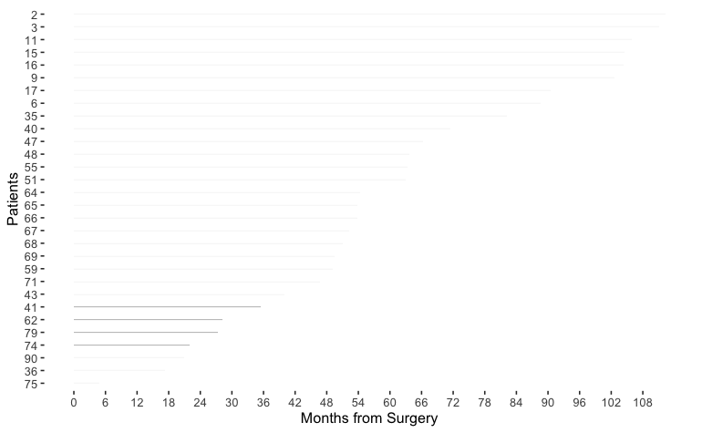

```r
library(swimplot)
library(ggplot2)
library(grid)
library(gtable)

##Overview plot
setwd("~/Downloads")
clinstage<- read.csv("IRST_Rectal_OP.csv")
clinstage_df<- as.data.frame(clinstage)

#Display the swimmer plot with the label box
oplot<-swimmer_plot(df=clinstage_df,
                    id='PatientName',
                    end='fu.diff.months',
                    fill='gray',
                    width=.01,)
oplot <- oplot + theme(panel.border = element_blank())
oplot <- oplot + scale_y_continuous(breaks = seq(-12, 108, by = 6))
oplot <- oplot + labs(x ="Patients" , y="Months from Surgery")
oplot
```

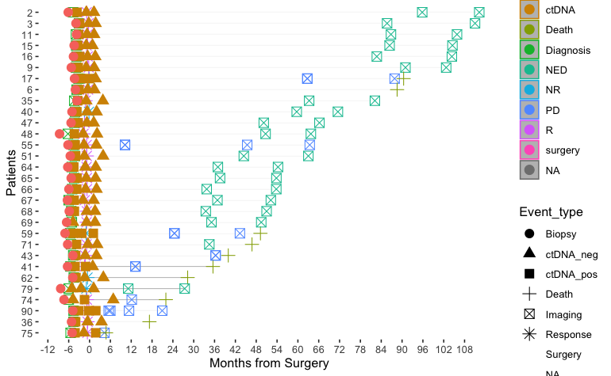

```r
##plot events
oplot_ev1 <- oplot + swimmer_points(df_points=clinstage_df,
                                    id='PatientName',
                                    time='date.diff.months',
                                    name_shape ='Event_type',
                                    name_col = 'Event',
                                    size=3.5,fill='black',
                                    #col='darkgreen'
)
oplot_ev1
```

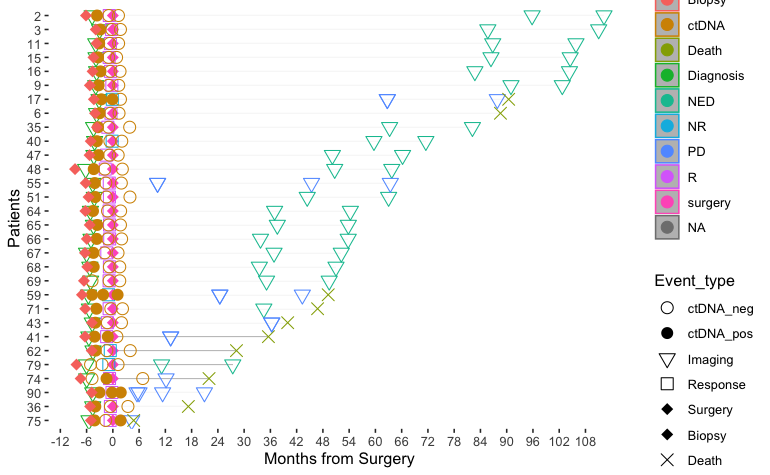

```r
#Shape customization to Event_type

oplot_ev1.1 <- oplot_ev1 + ggplot2::scale_shape_manual(name="Event_type",values=c(1,16,6,0,18,18,4),breaks=c('ctDNA_neg','ctDNA_pos','Imaging','Response','Surgery','Biopsy', 'Death'))

oplot_ev1.1
```

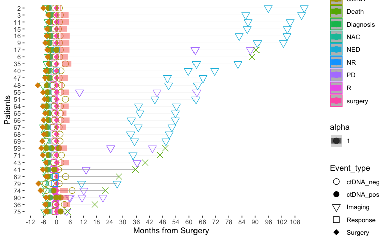

```r
#plot treatment

oplot_ev2 <- oplot_ev1.1 + swimmer_lines(df_lines=clinstage_df,
                                         id='PatientName',
                                         start='Tx_start.months',
                                         end='Tx_end.months',
                                         name_col='Tx_type',
                                         size=3.5,
                                         name_alpha = 1.0)
oplot_ev2 <- oplot_ev2 + guides(linetype = guide_legend(override.aes = list(size = 5, color = "black")))
oplot_ev2
```

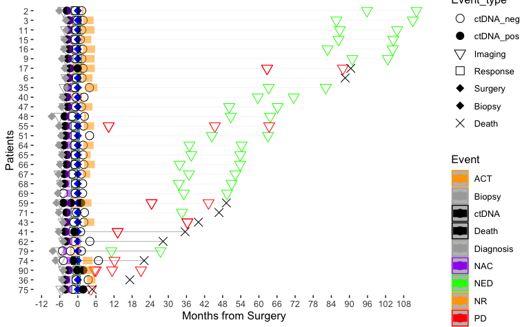

```r
#colour customization
##Dark Gray=MRI diagnosis, purple=ACT, Black=Death, Red=PD, ctDNA negative=white, ctDNA positive=black, surgery=blue, Resp=Dark Green,
oplot_ev2.2 <- oplot_ev2 + ggplot2::scale_color_manual(name="Event",values=c( "orange","darkgray","black", "black", "darkgray", "purple", "green", "orange", "red", "darkgreen", "blue"))
oplot_ev2.2
```

#DFS by ctDNA post-NAT

```r
rm(list=ls())
setwd("~/Downloads")
circ_data <- read.csv("Rectal IRST_Clinical Data.csv")
circ_datadf <- as.data.frame(circ_data)

survfit(Surv(time = circ_data$DFS.months, event = circ_data$DFS.Event)~ctDNA.postNAC, data = circ_data)
```

```
Call: survfit(formula = Surv(time = circ_data$DFS.months, event = circ_data$DFS.Event) ~
    ctDNA.postNAC, data = circ_data)

                        n events median 0.95LCL 0.95UCL
ctDNA.postNAC=NEGATIVE 25      7     NA    88.6      NA
ctDNA.postNAC=POSITIVE  5      5   13.2    12.2      NA
```

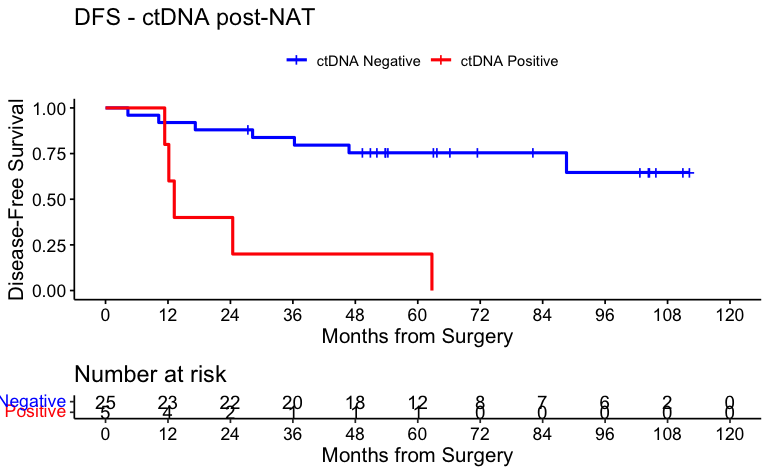

```r
surv_object <-Surv(time = circ_data$DFS.months, event = circ_data$DFS.Event)
KM_curve <- survfit(surv_object ~ ctDNA.postNAC, data = circ_data,conf.int=0.95,conf.type="log-log")
ggsurvplot(KM_curve, data = circ_data, pval = FALSE, conf.int = FALSE, risk.table = TRUE, break.time.by=12, palette=c("blue","red"), title="DFS - ctDNA post-NAT", ylab= "Disease-Free Survival", xlab="Months from Surgery", legend.labs=c("ctDNA Negative", "ctDNA Positive"), legend.title="")
```

```r
summary(KM_curve, times= c(12))
```

```
Call: survfit(formula = surv_object ~ ctDNA.postNAC, data = circ_data,
    conf.int = 0.95, conf.type = "log-log")

                ctDNA.postNAC=NEGATIVE
        time       n.risk      n.event     survival      std.err lower 95% CI upper 95% CI
     12.0000      23.0000       2.0000       0.9200       0.0543       0.7164       0.9794

                ctDNA.postNAC=POSITIVE
        time       n.risk      n.event     survival      std.err lower 95% CI upper 95% CI
      12.000        4.000        1.000        0.800        0.179        0.204        0.969
```

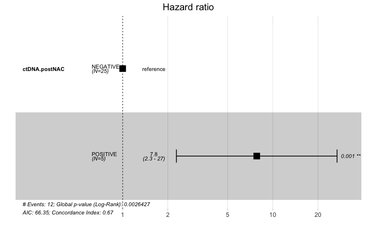

```r
circ_data$ctDNA.postNAC <- factor(circ_data$ctDNA.postNAC, levels=c("NEGATIVE","POSITIVE"))
cox_fit <- coxph(surv_object ~ ctDNA.postNAC, data=circ_data)
ggforest(cox_fit,data = circ_data)
```

```r
summary(cox_fit)
```

```
Call:
coxph(formula = surv_object ~ ctDNA.postNAC, data = circ_data)

  n= 30, number of events= 12

                        coef exp(coef) se(coef)     z Pr(>|z|)
ctDNA.postNACPOSITIVE 2.0570    7.8221   0.6287 3.272  0.00107 **
---
Signif. codes:  0 ‘***’ 0.001 ‘**’ 0.01 ‘*’ 0.05 ‘.’ 0.1 ‘ ’ 1

                      exp(coef) exp(-coef) lower .95 upper .95
ctDNA.postNACPOSITIVE     7.822     0.1278     2.281     26.82

Concordance= 0.669  (se = 0.064 )
Likelihood ratio test= 9.04  on 1 df,   p=0.003
Wald test            = 10.7  on 1 df,   p=0.001
Score (logrank) test = 14.51  on 1 df,   p=1e-04
```

```r
cox_fit_summary <- summary(cox_fit)

#Extract values for HR, 95% CI, and p-value
HR <- cox_fit_summary$coefficients[2]
lower_CI <- cox_fit_summary$conf.int[3]
upper_CI <- cox_fit_summary$conf.int[4]
p_value <- cox_fit_summary$coefficients[5]
label_text <- paste0("HR = ", round(HR, 2), " (", round(lower_CI, 2), "-", round(upper_CI, 2), "); p = ", round(p_value, 3))
print(label_text)
```

```
[1] "HR = 7.82 (2.28-26.82); p = 0.001"
```

```r
#Fisher plot for ctDNA post-NAT and Rec Status
circ_data$ctDNA.postNAC <- factor(circ_data$ctDNA.postNAC, levels = c("NEGATIVE", "POSITIVE"), labels = c("ctDNA(-)", "ctDNA(+)"))
circ_data$DFS.Event <- factor(circ_data$DFS.Event, levels = c("FALSE", "TRUE"), labels = c("No Recurrence", "Recurrence"))
contingency_table <- table(circ_data$ctDNA.postNAC, circ_data$DFS.Event)
chi_square_test <- chisq.test(contingency_table)
print(chi_square_test)
```

```
    Pearson's Chi-squared test with Yates' continuity correction

data:  contingency_table
X-squared = 6.25, df = 1, p-value = 0.01242
```

```r
fisher_exact_test <- fisher.test(contingency_table)
print(fisher_exact_test)
```

```
    Fisher's Exact Test for Count Data

data:  contingency_table
p-value = 0.005558
alternative hypothesis: true odds ratio is not equal to 1
95 percent confidence interval:
 1.742654      Inf
sample estimates:
odds ratio
       Inf
```

```r
print(contingency_table)
```

```
           No Recurrence Recurrence
  ctDNA(-)            18          7
  ctDNA(+)             0          5
```

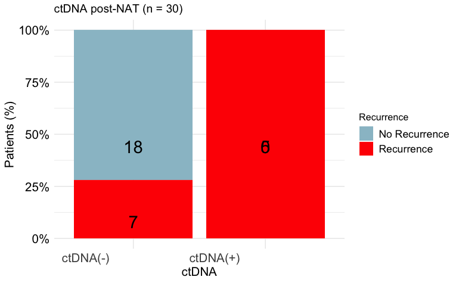

```r
table_df <- as.data.frame(contingency_table)
table_df$Total <- ave(table_df$Freq, table_df$Var1, FUN = sum)
table_df$Percentage <- table_df$Freq / table_df$Total
table_df$MiddlePercentage <- table_df$Percentage / 2
ggplot(table_df, aes(x = Var1, y = Percentage, fill = Var2)) +
  geom_bar(stat = "identity") +
  geom_text(aes(y = MiddlePercentage, label = Freq), position = "stack", color = "black", vjust = 1.5, size = 7) +
  theme_minimal() +
  labs(title = "ctDNA post-NAT (n = 30)", x = "ctDNA", y = "Patients (%)", fill = "Recurrence") +
  scale_y_continuous(labels = scales::percent_format()) +
  scale_fill_manual(values = c("No Recurrence" = "lightblue3", "Recurrence" = "red")) + # define custom colors
  theme(axis.text.x = element_text(angle = 0, hjust = 1.5, size = 14), # increase x-axis text size
        axis.text.y = element_text(size = 14, color = "black"), # increase y-axis text size
        axis.title.x = element_text(size = 14, color = "black"), # increase x-axis label size
        axis.title.y = element_text(size = 14, color = "black"), # increase y-axis label size
        legend.text = element_text(size = 12, color = "black"))  # increase Recurrence label size
```

#DFS by ctDNA clearance post-NAT

```r
rm(list=ls())
setwd("~/Downloads")
circ_data <- read.csv("Rectal IRST_Clinical Data.csv")
circ_datadf <- as.data.frame(circ_data)

survfit(Surv(time = circ_data$DFS.months, event = circ_data$DFS.Event)~ctDNA.NAC.Clearance, data = circ_data)
```

```
Call: survfit(formula = Surv(time = circ_data$DFS.months, event = circ_data$DFS.Event) ~
    ctDNA.NAC.Clearance, data = circ_data)

   3 observations deleted due to missingness
                           n events median 0.95LCL 0.95UCL
ctDNA.NAC.Clearance=FALSE  4      4   18.8    11.4      NA
ctDNA.NAC.Clearance=TRUE  23      7     NA    88.6      NA
```

[figure not shown]

```r
surv_object <-Surv(time = circ_data$DFS.months, event = circ_data$DFS.Event)
KM_curve <- survfit(surv_object ~ ctDNA.NAC.Clearance, data = circ_data,conf.int=0.95,conf.type="log-log")
ggsurvplot(KM_curve, data = circ_data, pval = FALSE, conf.int = FALSE, risk.table = TRUE, break.time.by=12, palette=c("blue","red"), title="DFS - ctDNA Clearance post-NAT", ylab= "Disease-Free Survival", xlab="Months from Surgery", legend.labs=c("Clearance", "No Clearance"), legend.title="")
```

```r
summary(KM_curve, times= c(12))
```

```
Call: survfit(formula = surv_object ~ ctDNA.NAC.Clearance, data = circ_data,
    conf.int = 0.95, conf.type = "log-log")

3 observations deleted due to missingness
                ctDNA.NAC.Clearance=FALSE
        time       n.risk      n.event     survival      std.err lower 95% CI upper 95% CI
      12.000        3.000        1.000        0.750        0.217        0.128        0.961

                ctDNA.NAC.Clearance=TRUE
        time       n.risk      n.event     survival      std.err lower 95% CI upper 95% CI
     12.0000      21.0000       2.0000       0.9130       0.0588       0.6949       0.9775
```

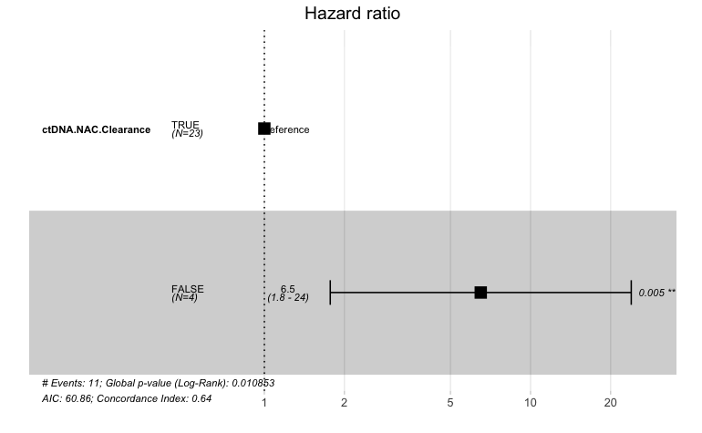

```r
circ_data$ctDNA.NAC.Clearance <- factor(circ_data$ctDNA.NAC.Clearance, levels=c("TRUE","FALSE"))
cox_fit <- coxph(surv_object ~ ctDNA.NAC.Clearance, data=circ_data)
ggforest(cox_fit,data = circ_data)
```

```r
summary(cox_fit)
```

```
Call:
coxph(formula = surv_object ~ ctDNA.NAC.Clearance, data = circ_data)

  n= 27, number of events= 11
   (3 observations deleted due to missingness)

                           coef exp(coef) se(coef)     z Pr(>|z|)
ctDNA.NAC.ClearanceFALSE 1.8718    6.4998   0.6642 2.818  0.00483 **
---
Signif. codes:  0 ‘***’ 0.001 ‘**’ 0.01 ‘*’ 0.05 ‘.’ 0.1 ‘ ’ 1

                         exp(coef) exp(-coef) lower .95 upper .95
ctDNA.NAC.ClearanceFALSE       6.5     0.1539     1.768     23.89

Concordance= 0.641  (se = 0.064 )
Likelihood ratio test= 6.49  on 1 df,   p=0.01
Wald test            = 7.94  on 1 df,   p=0.005
Score (logrank) test = 10.33  on 1 df,   p=0.001
```

```r
cox_fit_summary <- summary(cox_fit)

#Extract values for HR, 95% CI, and p-value
HR <- cox_fit_summary$coefficients[2]
lower_CI <- cox_fit_summary$conf.int[3]
upper_CI <- cox_fit_summary$conf.int[4]
p_value <- cox_fit_summary$coefficients[5]
label_text <- paste0("HR = ", round(HR, 2), " (", round(lower_CI, 2), "-", round(upper_CI, 2), "); p = ", round(p_value, 3))
print(label_text)
```

```
[1] "HR = 6.5 (1.77-23.89); p = 0.005"
```

```r
#Fisher plot for ctDNA clearance post-NAT and Rec Status
circ_data$ctDNA.NAC.Clearance <- factor(circ_data$ctDNA.NAC.Clearance, levels = c("TRUE", "FALSE"), labels = c("Clearance", "No Clearance"))
circ_data$DFS.Event <- factor(circ_data$DFS.Event, levels = c("FALSE", "TRUE"), labels = c("No Recurrence", "Recurrence"))
contingency_table <- table(circ_data$ctDNA.NAC.Clearance, circ_data$DFS.Event)
chi_square_test <- chisq.test(contingency_table)
print(chi_square_test)
```

```
    Pearson's Chi-squared test with Yates' continuity correction

data:  contingency_table
X-squared = 4.2525, df = 1, p-value = 0.03919
```

```r
fisher_exact_test <- fisher.test(contingency_table)
print(fisher_exact_test)
```

```
    Fisher's Exact Test for Count Data

data:  contingency_table
p-value = 0.0188
alternative hypothesis: true odds ratio is not equal to 1
95 percent confidence interval:
 1.130759      Inf
sample estimates:
odds ratio
       Inf
```

```r
print(contingency_table)
```

```
               No Recurrence Recurrence
  Clearance               16          7
  No Clearance             0          4
```

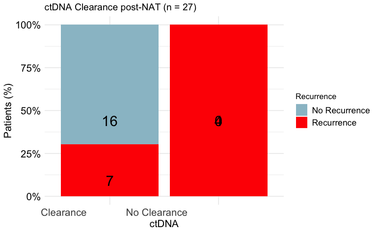

```r
table_df <- as.data.frame(contingency_table)
table_df$Total <- ave(table_df$Freq, table_df$Var1, FUN = sum)
table_df$Percentage <- table_df$Freq / table_df$Total
table_df$MiddlePercentage <- table_df$Percentage / 2
ggplot(table_df, aes(x = Var1, y = Percentage, fill = Var2)) +
  geom_bar(stat = "identity") +
  geom_text(aes(y = MiddlePercentage, label = Freq), position = "stack", color = "black", vjust = 1.5, size = 7) +
  theme_minimal() +
  labs(title = "ctDNA Clearance post-NAT (n = 27)", x = "ctDNA", y = "Patients (%)", fill = "Recurrence") +
  scale_y_continuous(labels = scales::percent_format()) +
  scale_fill_manual(values = c("No Recurrence" = "lightblue3", "Recurrence" = "red")) + # define custom colors
  theme(axis.text.x = element_text(angle = 0, hjust = 1.5, size = 14), # increase x-axis text size
        axis.text.y = element_text(size = 14, color = "black"), # increase y-axis text size
        axis.title.x = element_text(size = 14, color = "black"), # increase x-axis label size
        axis.title.y = element_text(size = 14, color = "black"), # increase y-axis label size
        legend.text = element_text(size = 12, color = "black"))  # increase Recurrence label size
```

```r
rm(list=ls())
setwd("~/Downloads")
circ_data <- read.csv("Rectal IRST_Clinical Data.csv")

#Fisher plot for ctDNA clearance post-NAT and Rec Status
circ_data$ctDNA.NAC.Clearance <- factor(circ_data$ctDNA.NAC.Clearance, levels = c("TRUE", "FALSE"), labels = c("Clearance", "No Clearance"))
circ_data$Downstaging <- factor(circ_data$Downstaging, levels = c("R", "NR"), labels = c("Responders", "Non-Responders"))
contingency_table <- table(circ_data$ctDNA.NAC.Clearance, circ_data$Downstaging)
fisher_exact_test <- fisher.test(contingency_table)
print(fisher_exact_test)
```

```
    Fisher's Exact Test for Count Data

data:  contingency_table
p-value = 0.09179
alternative hypothesis: true odds ratio is not equal to 1
95 percent confidence interval:
   0.4442762 204.4797745
sample estimates:
odds ratio
  9.059876
```

```r
print(contingency_table)
```

```
               Responders Non-Responders
  Clearance            21              2
  No Clearance          2              2
```

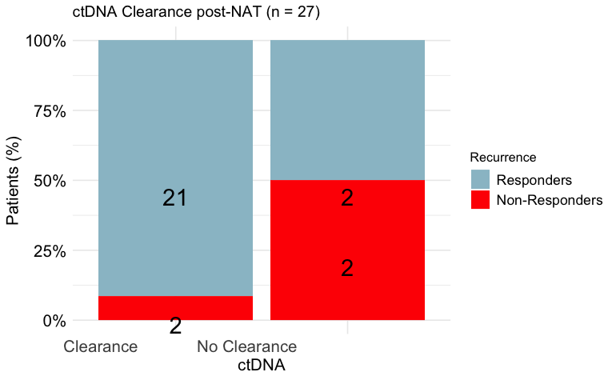

```r
table_df <- as.data.frame(contingency_table)
table_df$Total <- ave(table_df$Freq, table_df$Var1, FUN = sum)
table_df$Percentage <- table_df$Freq / table_df$Total
table_df$MiddlePercentage <- table_df$Percentage / 2
ggplot(table_df, aes(x = Var1, y = Percentage, fill = Var2)) +
  geom_bar(stat = "identity") +
  geom_text(aes(y = MiddlePercentage, label = Freq), position = "stack", color = "black", vjust = 1.5, size = 7) +
  theme_minimal() +
  labs(title = "ctDNA Clearance post-NAT (n = 27)", x = "ctDNA", y = "Patients (%)", fill = "Recurrence") +
  scale_y_continuous(labels = scales::percent_format()) +
  scale_fill_manual(values = c("Responders" = "lightblue3", "Non-Responders" = "red")) + # define custom colors
  theme(axis.text.x = element_text(angle = 0, hjust = 1.5, size = 14), # increase x-axis text size
        axis.text.y = element_text(size = 14, color = "black"), # increase y-axis text size
        axis.title.x = element_text(size = 14, color = "black"), # increase x-axis label size
        axis.title.y = element_text(size = 14, color = "black"), # increase y-axis label size
        legend.text = element_text(size = 12, color = "black"))  # increase Recurrence label size
```

```r
rm(list=ls())
setwd("~/Downloads")
circ_data <- read.csv("Rectal IRST_Clinical Data.csv")

#Vertical Fisher plot for ctDNA clearance post-NAT and Rec Status
circ_data$ctDNA.NAC.Clearance <- factor(circ_data$ctDNA.NAC.Clearance, levels = c("TRUE", "FALSE"), labels = c("Clearance", "No Clearance"))
circ_data$Downstaging <- factor(circ_data$Downstaging, levels = c("R", "NR"), labels = c("Responders", "Non-Responders"))
contingency_table <- table(circ_data$ctDNA.NAC.Clearance, circ_data$Downstaging)
fisher_exact_test <- fisher.test(contingency_table)
chi_square_test <- chisq.test(contingency_table)
print(chi_square_test)
```

```
    Pearson's Chi-squared test with Yates' continuity correction

data:  contingency_table
X-squared = 1.9148, df = 1, p-value = 0.1664
```

```r
print(fisher_exact_test)
```

```
    Fisher's Exact Test for Count Data

data:  contingency_table
p-value = 0.09179
alternative hypothesis: true odds ratio is not equal to 1
95 percent confidence interval:
   0.4442762 204.4797745
sample estimates:
odds ratio
  9.059876
```

```r
print(contingency_table)
```

```
               Responders Non-Responders
  Clearance            21              2
  No Clearance          2              2
```

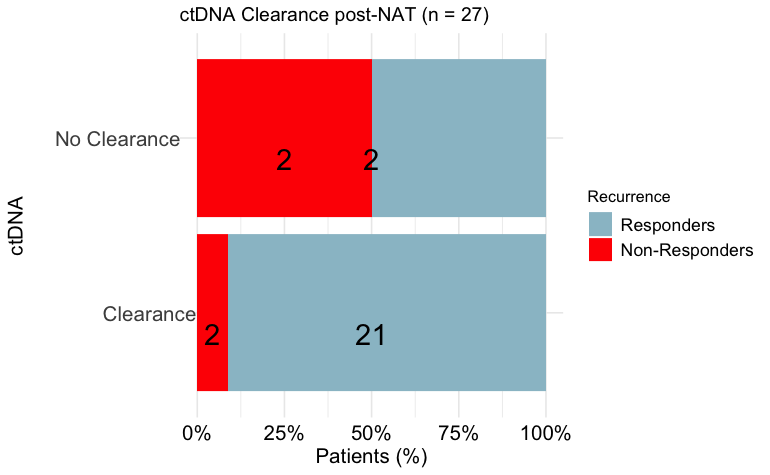

```r
table_df <- as.data.frame(contingency_table)
table_df$Total <- ave(table_df$Freq, table_df$Var1, FUN = sum)
table_df$Percentage <- table_df$Freq / table_df$Total
table_df$MiddlePercentage <- table_df$Percentage / 2

# Swapping x and y in ggplot function to make bar plot vertical
ggplot(table_df, aes(y = Var1, x = Percentage, fill = Var2)) +
  geom_bar(stat = "identity") +
  geom_text(aes(x = MiddlePercentage, label = Freq), position = "stack", color = "black", vjust = 1.5, size = 7) +
  theme_minimal() +
  labs(title = "ctDNA Clearance post-NAT (n = 27)", y = "ctDNA", x = "Patients (%)", fill = "Recurrence") +
  scale_x_continuous(labels = scales::percent_format()) +
  scale_fill_manual(values = c("Responders" = "lightblue3", "Non-Responders" = "red")) + # define custom colors
  theme(axis.text.y = element_text(angle = 0, hjust = 1.5, size = 14), # increase y-axis text size
        axis.text.x = element_text(size = 14, color = "black"), # increase x-axis text size
        axis.title.y = element_text(size = 14, color = "black"), # increase y-axis label size
        axis.title.x = element_text(size = 14, color = "black"), # increase x-axis label size
        legend.text = element_text(size = 12, color = "black"))  # increase Recurrence label size
```

```r
rm(list=ls())
setwd("~/Downloads")
circ_data <- read.csv("Rectal IRST_Clinical Data.csv")

circ_data$ctDNA.NAC.Clearance <- factor(circ_data$ctDNA.NAC.Clearance, levels = c("FALSE", "TRUE"))
circ_data$Downstaging <- factor(circ_data$Downstaging, levels = c("NR", "R"))

logit_model <- glm(Downstaging ~ ctDNA.NAC.Clearance, data = circ_data, family = "binomial")
summary(logit_model)
```

```
Call:
glm(formula = Downstaging ~ ctDNA.NAC.Clearance, family = "binomial",
    data = circ_data)

Deviance Residuals:
    Min       1Q   Median       3Q      Max
-2.2101   0.4265   0.4265   0.4265   1.1774

Coefficients:
                          Estimate Std. Error z value Pr(>|z|)
(Intercept)             -1.585e-15  1.000e+00    0.00   1.0000
ctDNA.NAC.ClearanceTRUE  2.351e+00  1.244e+00    1.89   0.0587 .
---
Signif. codes:  0 ‘***’ 0.001 ‘**’ 0.01 ‘*’ 0.05 ‘.’ 0.1 ‘ ’ 1

(Dispersion parameter for binomial family taken to be 1)

    Null deviance: 22.652  on 26  degrees of freedom
Residual deviance: 19.135  on 25  degrees of freedom
  (3 observations deleted due to missingness)
AIC: 23.135

Number of Fisher Scoring iterations: 5
```

```r
OR <- exp(coef(logit_model))
CI <- exp(confint(logit_model))
P_values <- summary(logit_model)$coefficients[,4]
result <- data.frame(
  OddsRatio = OR,
  Lower95CI = CI[, 1],
  Upper95CI = CI[, 2],
  Pvalue = P_values)
print(result)
```

|  | OddsRatio | Lower95CI | Upper95CI | Pvalue |
| --- | --- | --- | --- | --- |
| (Intercept) | 1.0 | 0.1199776 | 8.334891 | 1.00000000 |
| ctDNA.NAC.ClearanceTRUE | 10.5 | 0.8923342 | 148.452227 | 0.05874159 |

#DFS by ctDNA at MRD time point

```r
rm(list=ls())
setwd("~/Downloads")
circ_data <- read.csv("Rectal IRST_Clinical Data.csv")
circ_data <- circ_data[circ_data$ctDNA.MRD!="",]
circ_data$DFS.months=circ_data$DFS.months-3
circ_data <- circ_data[circ_data$DFS.months>=0,]
circ_datadf <- as.data.frame(circ_data)

survfit(Surv(time = circ_data$DFS.months, event = circ_data$DFS.Event)~ctDNA.MRD, data = circ_data)
```

```
Call: survfit(formula = Surv(time = circ_data$DFS.months, event = circ_data$DFS.Event) ~
    ctDNA.MRD, data = circ_data)

                    n events median 0.95LCL 0.95UCL
ctDNA.MRD=NEGATIVE 22      6     NA    85.6      NA
ctDNA.MRD=POSITIVE  3      3   8.37     1.3      NA
```

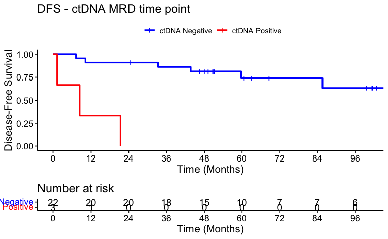

```r
surv_object <-Surv(time = circ_data$DFS.months, event = circ_data$DFS.Event)
KM_curve <- survfit(surv_object ~ ctDNA.MRD, data = circ_data,conf.int=0.95,conf.type="log-log")
ggsurvplot(KM_curve, data = circ_data, pval = FALSE, conf.int = FALSE, risk.table = TRUE, break.time.by=12, palette=c("blue","red"), title="DFS - ctDNA MRD time point", ylab= "Disease-Free Survival", xlab="Time (Months)", legend.labs=c("ctDNA Negative", "ctDNA Positive"), legend.title="")
```

```r
summary(KM_curve, times= c(12))
```

```
Call: survfit(formula = surv_object ~ ctDNA.MRD, data = circ_data,
    conf.int = 0.95, conf.type = "log-log")

                ctDNA.MRD=NEGATIVE
        time       n.risk      n.event     survival      std.err lower 95% CI upper 95% CI
     12.0000      20.0000       2.0000       0.9091       0.0613       0.6830       0.9765

                ctDNA.MRD=POSITIVE
        time       n.risk      n.event     survival      std.err lower 95% CI upper 95% CI
    12.00000      1.00000      2.00000      0.33333      0.27217      0.00896      0.77415
```

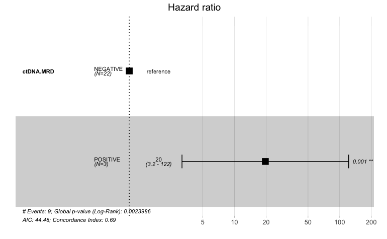

```r
circ_data$ctDNA.MRD <- factor(circ_data$ctDNA.MRD, levels=c("NEGATIVE","POSITIVE"))
cox_fit <- coxph(surv_object ~ ctDNA.MRD, data=circ_data)
ggforest(cox_fit,data = circ_data)
```

```r
summary(cox_fit)
```

```
Call:
coxph(formula = surv_object ~ ctDNA.MRD, data = circ_data)

  n= 25, number of events= 9

                     coef exp(coef) se(coef)   z Pr(>|z|)
ctDNA.MRDPOSITIVE  2.9780   19.6490   0.9306 3.2  0.00137 **
---
Signif. codes:  0 ‘***’ 0.001 ‘**’ 0.01 ‘*’ 0.05 ‘.’ 0.1 ‘ ’ 1

                  exp(coef) exp(-coef) lower .95 upper .95
ctDNA.MRDPOSITIVE     19.65    0.05089     3.171     121.8

Concordance= 0.686  (se = 0.077 )
Likelihood ratio test= 9.22  on 1 df,   p=0.002
Wald test            = 10.24  on 1 df,   p=0.001
Score (logrank) test = 19.56  on 1 df,   p=1e-05
```

```r
cox_fit_summary <- summary(cox_fit)

#Extract values for HR, 95% CI, and p-value
HR <- cox_fit_summary$coefficients[2]
lower_CI <- cox_fit_summary$conf.int[3]
upper_CI <- cox_fit_summary$conf.int[4]
p_value <- cox_fit_summary$coefficients[5]
label_text <- paste0("HR = ", round(HR, 2), " (", round(lower_CI, 2), "-", round(upper_CI, 2), "); p = ", round(p_value, 3))
print(label_text)
```

```
[1] "HR = 19.65 (3.17-121.75); p = 0.001"
```

```r
#Fisher plot for ctDNA MRD time point and Rec Status
circ_data$ctDNA.MRD <- factor(circ_data$ctDNA.MRD, levels = c("NEGATIVE", "POSITIVE"), labels = c("ctDNA(-)", "ctDNA(+)"))
circ_data$DFS.Event <- factor(circ_data$DFS.Event, levels = c("FALSE", "TRUE"), labels = c("No Recurrence", "Recurrence"))
contingency_table <- table(circ_data$ctDNA.MRD, circ_data$DFS.Event)
chi_square_test <- chisq.test(contingency_table)
print(chi_square_test)
```

```
    Pearson's Chi-squared test with Yates' continuity correction

data:  contingency_table
X-squared = 3.3151, df = 1, p-value = 0.06865
```

```r
fisher_exact_test <- fisher.test(contingency_table)
print(fisher_exact_test)
```

```
    Fisher's Exact Test for Count Data

data:  contingency_table
p-value = 0.03652
alternative hypothesis: true odds ratio is not equal to 1
95 percent confidence interval:
 0.8257527       Inf
sample estimates:
odds ratio
       Inf
```

```r
print(contingency_table)
```

```
           No Recurrence Recurrence
  ctDNA(-)            16          6
  ctDNA(+)             0          3
```

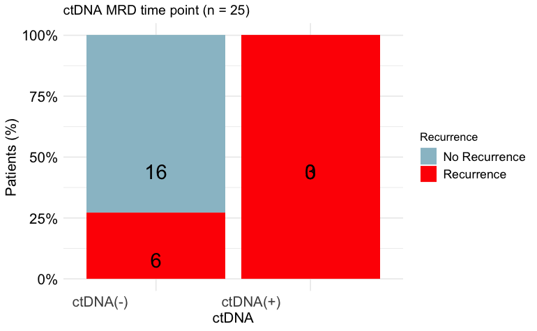

```r
table_df <- as.data.frame(contingency_table)
table_df$Total <- ave(table_df$Freq, table_df$Var1, FUN = sum)
table_df$Percentage <- table_df$Freq / table_df$Total
table_df$MiddlePercentage <- table_df$Percentage / 2
ggplot(table_df, aes(x = Var1, y = Percentage, fill = Var2)) +
  geom_bar(stat = "identity") +
  geom_text(aes(y = MiddlePercentage, label = Freq), position = "stack", color = "black", vjust = 1.5, size = 7) +
  theme_minimal() +
  labs(title = "ctDNA MRD time point (n = 25)", x = "ctDNA", y = "Patients (%)", fill = "Recurrence") +
  scale_y_continuous(labels = scales::percent_format()) +
  scale_fill_manual(values = c("No Recurrence" = "lightblue3", "Recurrence" = "red")) + # define custom colors
  theme(axis.text.x = element_text(angle = 0, hjust = 1.5, size = 14), # increase x-axis text size
        axis.text.y = element_text(size = 14, color = "black"), # increase y-axis text size
        axis.title.x = element_text(size = 14, color = "black"), # increase x-axis label size
        axis.title.y = element_text(size = 14, color = "black"), # increase y-axis label size
        legend.text = element_text(size = 12, color = "black"))  # increase Recurrence label size
```

#DFS by ctDNA at post-surgery

```r
rm(list=ls())
setwd("~/Downloads")
circ_data <- read.csv("Rectal IRST_Clinical Data.csv")
circ_datadf <- as.data.frame(circ_data)

survfit(Surv(time = circ_data$DFS.months, event = circ_data$DFS.Event)~ctDNA.postop, data = circ_data)
```

```
Call: survfit(formula = Surv(time = circ_data$DFS.months, event = circ_data$DFS.Event) ~
    ctDNA.postop, data = circ_data)

                       n events median 0.95LCL 0.95UCL
ctDNA.postop=NEGATIVE 27      9     NA    88.6      NA
ctDNA.postop=POSITIVE  3      3   11.4     4.3      NA
```

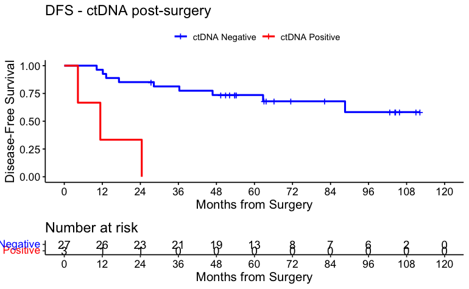

```r
surv_object <-Surv(time = circ_data$DFS.months, event = circ_data$DFS.Event)
KM_curve <- survfit(surv_object ~ ctDNA.postop, data = circ_data,conf.int=0.95,conf.type="log-log")
ggsurvplot(KM_curve, data = circ_data, pval = FALSE, conf.int = FALSE, risk.table = TRUE, break.time.by=12, palette=c("blue","red"), title="DFS - ctDNA post-surgery", ylab= "Disease-Free Survival", xlab="Months from Surgery", legend.labs=c("ctDNA Negative", "ctDNA Positive"), legend.title="")
```

```r
summary(KM_curve, times= c(12))
```

```
Call: survfit(formula = surv_object ~ ctDNA.postop, data = circ_data,
    conf.int = 0.95, conf.type = "log-log")

                ctDNA.postop=NEGATIVE
        time       n.risk      n.event     survival      std.err lower 95% CI upper 95% CI
     12.0000      26.0000       1.0000       0.9630       0.0363       0.7649       0.9947

                ctDNA.postop=POSITIVE
        time       n.risk      n.event     survival      std.err lower 95% CI upper 95% CI
    12.00000      1.00000      2.00000      0.33333      0.27217      0.00896      0.77415
```

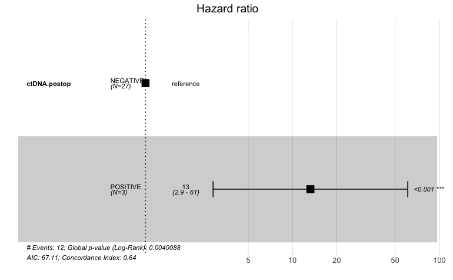

```r
circ_data$ctDNA.postop <- factor(circ_data$ctDNA.postop, levels=c("NEGATIVE","POSITIVE"))
cox_fit <- coxph(surv_object ~ ctDNA.postop, data=circ_data)
ggforest(cox_fit,data = circ_data)
```

```r
summary(cox_fit)
```

```
Call:
coxph(formula = surv_object ~ ctDNA.postop, data = circ_data)

  n= 30, number of events= 12

                        coef exp(coef) se(coef)    z Pr(>|z|)
ctDNA.postopPOSITIVE  2.5835   13.2436   0.7781 3.32 0.000899 ***
---
Signif. codes:  0 ‘***’ 0.001 ‘**’ 0.01 ‘*’ 0.05 ‘.’ 0.1 ‘ ’ 1

                     exp(coef) exp(-coef) lower .95 upper .95
ctDNA.postopPOSITIVE     13.24    0.07551     2.882     60.85

Concordance= 0.637  (se = 0.063 )
Likelihood ratio test= 8.28  on 1 df,   p=0.004
Wald test            = 11.03  on 1 df,   p=9e-04
Score (logrank) test = 18.23  on 1 df,   p=2e-05
```

```r
cox_fit_summary <- summary(cox_fit)

#Extract values for HR, 95% CI, and p-value
HR <- cox_fit_summary$coefficients[2]
lower_CI <- cox_fit_summary$conf.int[3]
upper_CI <- cox_fit_summary$conf.int[4]
p_value <- cox_fit_summary$coefficients[5]
label_text <- paste0("HR = ", round(HR, 2), " (", round(lower_CI, 2), "-", round(upper_CI, 2), "); p = ", round(p_value, 3))
print(label_text)
```

```
[1] "HR = 13.24 (2.88-60.85); p = 0.001"
```

```r
#Fisher plot for ctDNA post-surgery and Rec Status
circ_data$ctDNA.postop <- factor(circ_data$ctDNA.postop, levels = c("NEGATIVE", "POSITIVE"), labels = c("ctDNA(-)", "ctDNA(+)"))
circ_data$DFS.Event <- factor(circ_data$DFS.Event, levels = c("FALSE", "TRUE"), labels = c("No Recurrence", "Recurrence"))
contingency_table <- table(circ_data$ctDNA.postop, circ_data$DFS.Event)
chi_square_test <- chisq.test(contingency_table)
print(chi_square_test)
```

```
    Pearson's Chi-squared test with Yates' continuity correction

data:  contingency_table
X-squared = 2.608, df = 1, p-value = 0.1063
```

```r
fisher_exact_test <- fisher.test(contingency_table)
print(fisher_exact_test)
```

```
    Fisher's Exact Test for Count Data

data:  contingency_table
p-value = 0.05419
alternative hypothesis: true odds ratio is not equal to 1
95 percent confidence interval:
 0.6698606       Inf
sample estimates:
odds ratio
       Inf
```

```r
print(contingency_table)
```

```
           No Recurrence Recurrence
  ctDNA(-)            18          9
  ctDNA(+)             0          3
```

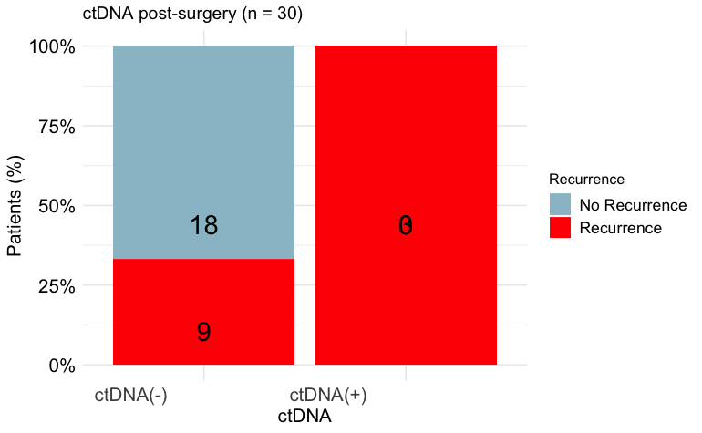

```r
table_df <- as.data.frame(contingency_table)
table_df$Total <- ave(table_df$Freq, table_df$Var1, FUN = sum)
table_df$Percentage <- table_df$Freq / table_df$Total
table_df$MiddlePercentage <- table_df$Percentage / 2
ggplot(table_df, aes(x = Var1, y = Percentage, fill = Var2)) +
  geom_bar(stat = "identity") +
  geom_text(aes(y = MiddlePercentage, label = Freq), position = "stack", color = "black", vjust = 1.5, size = 7) +
  theme_minimal() +
  labs(title = "ctDNA post-surgery (n = 30)", x = "ctDNA", y = "Patients (%)", fill = "Recurrence") +
  scale_y_continuous(labels = scales::percent_format()) +
  scale_fill_manual(values = c("No Recurrence" = "lightblue3", "Recurrence" = "red")) + # define custom colors
  theme(axis.text.x = element_text(angle = 0, hjust = 1.5, size = 14), # increase x-axis text size
        axis.text.y = element_text(size = 14, color = "black"), # increase y-axis text size
        axis.title.x = element_text(size = 14, color = "black"), # increase x-axis label size
        axis.title.y = element_text(size = 14, color = "black"), # increase y-axis label size
        legend.text = element_text(size = 12, color = "black"))  # increase Recurrence label size
```

#DFS by NAR score

```r
rm(list=ls())
setwd("~/Downloads")
circ_data <- read.csv("Rectal IRST_Clinical Data.csv")
circ_datadf <- as.data.frame(circ_data)

survfit(Surv(time = circ_data$DFS.months, event = circ_data$DFS.Event)~NAR.Status, data = circ_data)
```

```
Call: survfit(formula = Surv(time = circ_data$DFS.months, event = circ_data$DFS.Event) ~
    NAR.Status, data = circ_data)

                 n events median 0.95LCL 0.95UCL
NAR.Status=High  9      8   24.4    12.2      NA
NAR.Status=Low   9      0     NA      NA      NA
NAR.Status=Mid  12      4     NA    46.8      NA
```

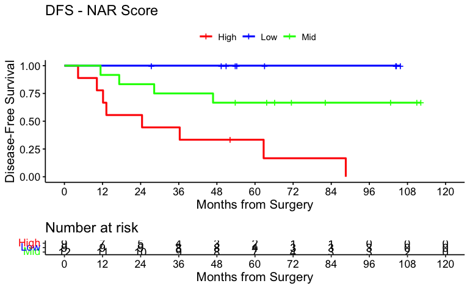

```r
surv_object <-Surv(time = circ_data$DFS.months, event = circ_data$DFS.Event)
KM_curve <- survfit(surv_object ~ NAR.Status, data = circ_data,conf.int=0.95,conf.type="log-log")
ggsurvplot(KM_curve, data = circ_data, pval = FALSE, conf.int = FALSE, risk.table = TRUE, break.time.by=12, palette=c("red","blue","green"), title="DFS - NAR Score", ylab= "Disease-Free Survival", xlab="Months from Surgery", legend.labs=c("High", "Low", "Mid"), legend.title="")
```

```r
summary(KM_curve, times= c(12))
```

```
Call: survfit(formula = surv_object ~ NAR.Status, data = circ_data,
    conf.int = 0.95, conf.type = "log-log")

                NAR.Status=High
        time       n.risk      n.event     survival      std.err lower 95% CI upper 95% CI
      12.000        7.000        2.000        0.778        0.139        0.365        0.939

                NAR.Status=Low
        time       n.risk      n.event     survival      std.err lower 95% CI upper 95% CI
          12            9            0            1            0            1            1

                NAR.Status=Mid
        time       n.risk      n.event     survival      std.err lower 95% CI upper 95% CI
     12.0000      11.0000       1.0000       0.9167       0.0798       0.5390       0.9878
```

```r
circ_data$NAR.Status <- factor(circ_data$NAR.Status, levels=c("Low","Mid","High"))
cox_fit <- coxphf(surv_object ~ NAR.Status, data=circ_data, firth=TRUE, pl=TRUE, maxit=1000)
summary(cox_fit)
```

```
coxphf(formula = surv_object ~ NAR.Status, data = circ_data,
    pl = TRUE, maxit = 1000, firth = TRUE)

Model fitted by Penalized ML
Confidence intervals and p-values by Profile Likelihood

                   coef se(coef) exp(coef) lower 0.95 upper 0.95     Chisq            p
NAR.StatusMid  1.992185 1.584534  7.331539  0.7811386   972.0415  2.906293 0.0882344495
NAR.StatusHigh 3.388167 1.548959 29.611635  3.6546958  3837.6720 13.490758 0.0002397413

Likelihood ratio test=14.08219 on 2 df, p=0.000875166, n=30
Wald test = 8.552634 on 2 df, p = 0.01389374

Covariance-Matrix:
               NAR.StatusMid NAR.StatusHigh
NAR.StatusMid       2.510748       2.260077
NAR.StatusHigh      2.260077       2.399275
```

```r
#Fisher plot for NAR Score and Rec Status
circ_data$NAR.Status <- factor(circ_data$NAR.Status, levels=c("Low","Mid","High"))
circ_data$DFS.Event <- factor(circ_data$DFS.Event, levels = c("FALSE", "TRUE"), labels = c("No Recurrence", "Recurrence"))
contingency_table <- table(circ_data$NAR.Status, circ_data$DFS.Event)
chi_square_test <- chisq.test(contingency_table)
print(chi_square_test)
```

```
    Pearson's Chi-squared test

data:  contingency_table
X-squared = 15.185, df = 2, p-value = 0.0005042
```

```r
fisher_exact_test <- fisher.test(contingency_table)
print(fisher_exact_test)
```

```
    Fisher's Exact Test for Count Data

data:  contingency_table
p-value = 0.0002174
alternative hypothesis: two.sided
```

```r
print(contingency_table)
```

```
       No Recurrence Recurrence
  Low              9          0
  Mid              8          4
  High             1          8
```

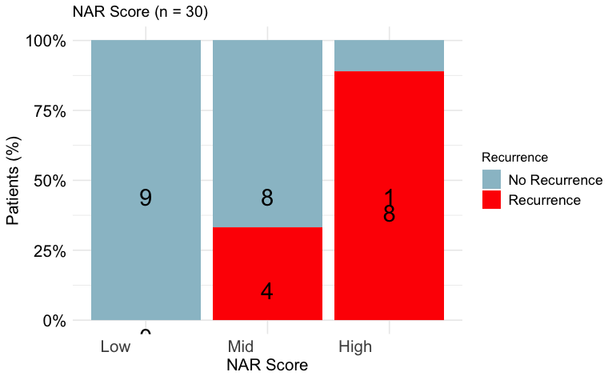

```r
table_df <- as.data.frame(contingency_table)
table_df$Total <- ave(table_df$Freq, table_df$Var1, FUN = sum)
table_df$Percentage <- table_df$Freq / table_df$Total
table_df$MiddlePercentage <- table_df$Percentage / 2
ggplot(table_df, aes(x = Var1, y = Percentage, fill = Var2)) +
  geom_bar(stat = "identity") +
  geom_text(aes(y = MiddlePercentage, label = Freq), position = "stack", color = "black", vjust = 1.5, size = 7) +
  theme_minimal() +
  labs(title = "NAR Score (n = 30)", x = "NAR Score", y = "Patients (%)", fill = "Recurrence") +
  scale_y_continuous(labels = scales::percent_format()) +
  scale_fill_manual(values = c("No Recurrence" = "lightblue3", "Recurrence" = "red")) + # define custom colors
  theme(axis.text.x = element_text(angle = 0, hjust = 1.5, size = 14), # increase x-axis text size
        axis.text.y = element_text(size = 14, color = "black"), # increase y-axis text size
        axis.title.x = element_text(size = 14, color = "black"), # increase x-axis label size
        axis.title.y = element_text(size = 14, color = "black"), # increase y-axis label size
        legend.text = element_text(size = 12, color = "black"))  # increase Recurrence label size
```

#Association of ctDNA post-NAT with NAR Score

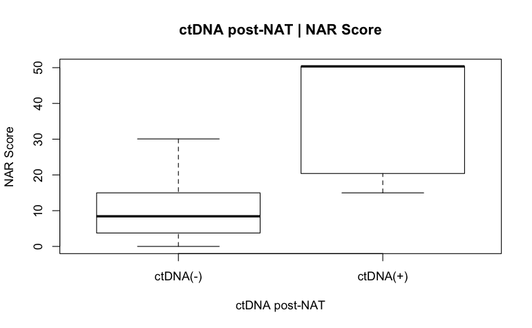

```r
#Boxplot & Fisher exact test for ctDNA post-NAT status with NAR score
rm(list=ls())
setwd("~/Downloads")
circ_data <- read.csv("Rectal IRST_Clinical Data.csv")
circ_datadf <- as.data.frame(circ_data)

circ_data$ctDNA.postNAC <- factor(circ_data$ctDNA.postNAC, levels = c("NEGATIVE", "POSITIVE"), labels = c("ctDNA(-)", "ctDNA(+)"))
circ_data$NAR.Status <- factor(circ_data$NAR.Status, levels = c("Low","Mid","High"), labels = c("Low","Mid","High"))

boxplot(NAR ~ ctDNA.postNAC, data=circ_data, main="ctDNA post-NAT | NAR Score", xlab="ctDNA post-NAT", ylab="NAR Score", col="white",border="black")
```

```r
m1 <- wilcox.test(NAR ~ ctDNA.postNAC, data=circ_data, na.rm=TRUE, paired=FALSE, exact=FALSE, conf.int=TRUE)
print(m1)
```

```
    Wilcoxon rank sum test with continuity correction

data:  NAR by ctDNA.postNAC
W = 11.5, p-value = 0.004455
alternative hypothesis: true location shift is not equal to 0
95 percent confidence interval:
 -41.93006 -11.22999
sample estimates:
difference in location
             -29.96004
```

```r
contingency_table <- table(circ_data$NAR.Status, circ_data$ctDNA.postNAC)
print(contingency_table)
```

```
       ctDNA(-) ctDNA(+)
  Low         9        0
  Mid        11        1
  High        5        4
```

```r
fisher_exact_test <- fisher.test(contingency_table)
print(fisher_exact_test)
```

```
    Fisher's Exact Test for Count Data

data:  contingency_table
p-value = 0.04446
alternative hypothesis: two.sided
```

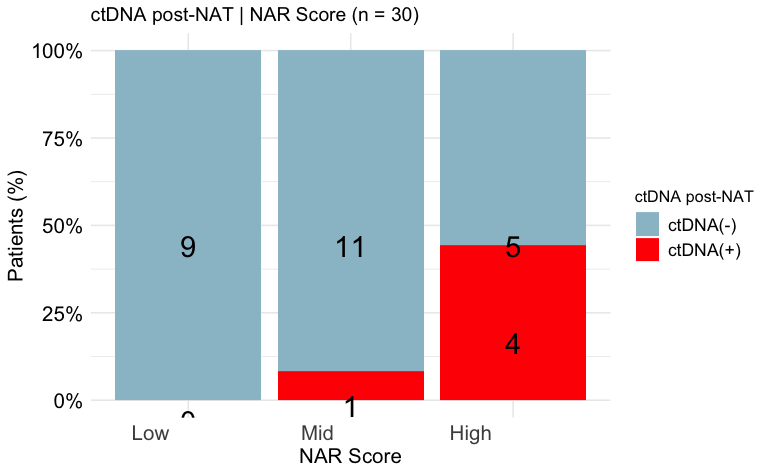

```r
table_df <- as.data.frame(contingency_table)
table_df$Total <- ave(table_df$Freq, table_df$Var1, FUN = sum)
table_df$Percentage <- table_df$Freq / table_df$Total
table_df$MiddlePercentage <- table_df$Percentage / 2
ggplot(table_df, aes(x = Var1, y = Percentage, fill = Var2)) +
  geom_bar(stat = "identity") +
  geom_text(aes(y = MiddlePercentage, label = Freq), position = "stack", color = "black", vjust = 1.5, size = 7) +
  theme_minimal() +
  labs(title = "ctDNA post-NAT | NAR Score (n = 30)", x = "NAR Score", y = "Patients (%)", fill = "ctDNA post-NAT") +
  scale_y_continuous(labels = scales::percent_format()) +
  scale_fill_manual(values = c("ctDNA(-)" = "lightblue3", "ctDNA(+)" = "red")) + # define custom colors
  theme(axis.text.x = element_text(angle = 0, hjust = 1.5, size = 14), # increase x-axis text size
        axis.text.y = element_text(size = 14, color = "black"), # increase y-axis text size
        axis.title.x = element_text(size = 14, color = "black"), # increase x-axis label size
        axis.title.y = element_text(size = 14, color = "black"), # increase y-axis label size
        legend.text = element_text(size = 12, color = "black"))  # increase Recurrence label size
```

#DFS by ctDNA at post-NAT and NAR Score - 3 groups

```r
rm(list=ls())
setwd("~/Downloads")
circ_data <- read.csv("Rectal IRST_Clinical Data.csv")

circ_data$ctDNA.postNAT.NAR <- NA #first we create the variable for the ctDNA & NAC combination, and we assign values
circ_data <- circ_data %>%
  mutate(ctDNA.postNAT.NAR = case_when(
    NAR.Score == "Low" & ctDNA.postNAC == "NEGATIVE" ~ 1,
    NAR.Score == "Mid/High" & ctDNA.postNAC == "NEGATIVE" ~ 2,
    NAR.Score == "Mid/High" & ctDNA.postNAC == "POSITIVE" ~ 3
  ))

survfit(Surv(time = circ_data$DFS.months, event = circ_data$DFS.Event)~ctDNA.postNAT.NAR, data = circ_data)
```

```
Call: survfit(formula = Surv(time = circ_data$DFS.months, event = circ_data$DFS.Event) ~
    ctDNA.postNAT.NAR, data = circ_data)

                     n events median 0.95LCL 0.95UCL
ctDNA.postNAT.NAR=1  9      0     NA      NA      NA
ctDNA.postNAT.NAR=2 16      7   88.6    36.3      NA
ctDNA.postNAT.NAR=3  5      5   13.2    12.2      NA
```

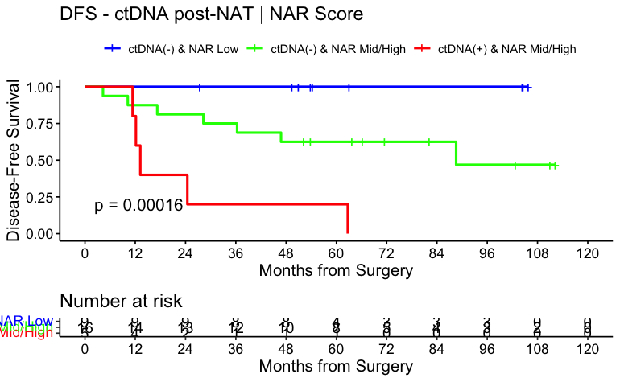

```r
surv_object <-Surv(time = circ_data$DFS.months, event = circ_data$DFS.Event)
KM_curve <- survfit(surv_object ~ ctDNA.postNAT.NAR, data = circ_data,conf.int=0.95,conf.type="log-log")
ggsurvplot(KM_curve, data = circ_data, pval = TRUE, conf.int = FALSE, risk.table = TRUE, break.time.by=12, palette=c("blue","green", "red"), title="DFS - ctDNA post-NAT | NAR Score", ylab= "Disease-Free Survival", xlab="Months from Surgery", legend.labs=c("ctDNA(-) & NAR Low", "ctDNA(-) & NAR Mid/High", "ctDNA(+) & NAR Mid/High"), legend.title="")
```

```r
summary(KM_curve, times= c(36))
```

```
Call: survfit(formula = surv_object ~ ctDNA.postNAT.NAR, data = circ_data,
    conf.int = 0.95, conf.type = "log-log")

                ctDNA.postNAT.NAR=1
        time       n.risk      n.event     survival      std.err lower 95% CI upper 95% CI
          36            8            0            1            0           NA           NA

                ctDNA.postNAT.NAR=2
        time       n.risk      n.event     survival      std.err lower 95% CI upper 95% CI
      36.000       12.000        4.000        0.750        0.108        0.463        0.898

                ctDNA.postNAT.NAR=3
        time       n.risk      n.event     survival      std.err lower 95% CI upper 95% CI
    36.00000      1.00000      4.00000      0.20000      0.17889      0.00837      0.58185
```

```r
circ_data$ctDNA.postNAT.NAR <- factor(circ_data$ctDNA.postNAT.NAR, levels=c("1", "2", "3"), labels = c("ctDNA(-) & NAR Low", "ctDNA(-) & NAR Mid/High", "ctDNA(+) & NAR Mid/High"))
cox_fit <- coxphf(surv_object ~ ctDNA.postNAT.NAR, data=circ_data)
summary(cox_fit)
```

```
coxphf(formula = surv_object ~ ctDNA.postNAT.NAR, data = circ_data)

Model fitted by Penalized ML
Confidence intervals and p-values by Profile Likelihood

                                             coef se(coef) exp(coef) lower 0.95 upper 0.95     Chisq            p
ctDNA.postNAT.NARctDNA(-) & NAR Mid/High 2.278706 1.549400  9.764036   1.188733   1267.619  4.700723 0.0301499343
ctDNA.postNAT.NARctDNA(+) & NAR Mid/High 3.861533 1.585868 47.538187   5.087168   6337.280 14.225859 0.0001621272

Likelihood ratio test=14.22784 on 2 df, p=0.0008136994, n=30
Wald test = 9.637369 on 2 df, p = 0.008077406

Covariance-Matrix:
                                         ctDNA.postNAT.NARctDNA(-) & NAR Mid/High ctDNA.postNAT.NARctDNA(+) & NAR Mid/High
ctDNA.postNAT.NARctDNA(-) & NAR Mid/High                                 2.400641                                 2.255337
ctDNA.postNAT.NARctDNA(+) & NAR Mid/High                                 2.255337                                 2.514977
```

```r
#Fisher plot for ctDNA post-NAT and NAR Score combination with Rec Status
circ_data$DFS.Event <- factor(circ_data$DFS.Event, levels = c("FALSE", "TRUE"), labels = c("No Recurrence", "Recurrence"))
contingency_table <- table(circ_data$ctDNA.postNAT.NAR, circ_data$DFS.Event)
chi_square_test <- chisq.test(contingency_table)
print(chi_square_test)
```

```
    Pearson's Chi-squared test

data:  contingency_table
X-squared = 13.594, df = 2, p-value = 0.001117
```

```r
fisher_exact_test <- fisher.test(contingency_table)
print(fisher_exact_test)
```

```
    Fisher's Exact Test for Count Data

data:  contingency_table
p-value = 0.00036
alternative hypothesis: two.sided
```

```r
print(contingency_table)
```

```
                          No Recurrence Recurrence
  ctDNA(-) & NAR Low                  9          0
  ctDNA(-) & NAR Mid/High             9          7
  ctDNA(+) & NAR Mid/High             0          5
```

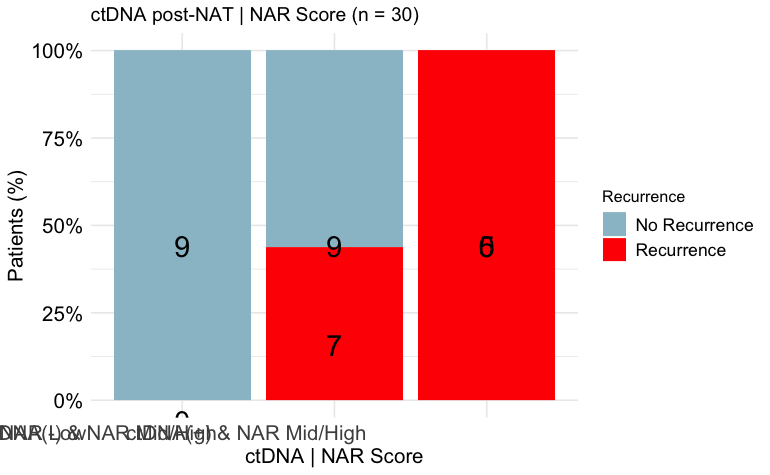

```r
table_df <- as.data.frame(contingency_table)
table_df$Total <- ave(table_df$Freq, table_df$Var1, FUN = sum)
table_df$Percentage <- table_df$Freq / table_df$Total
table_df$MiddlePercentage <- table_df$Percentage / 2
ggplot(table_df, aes(x = Var1, y = Percentage, fill = Var2)) +
  geom_bar(stat = "identity") +
  geom_text(aes(y = MiddlePercentage, label = Freq), position = "stack", color = "black", vjust = 1.5, size = 7) +
  theme_minimal() +
  labs(title = "ctDNA post-NAT | NAR Score (n = 30)", x = "ctDNA | NAR Score", y = "Patients (%)", fill = "Recurrence") +
  scale_y_continuous(labels = scales::percent_format()) +
  scale_fill_manual(values = c("No Recurrence" = "lightblue3", "Recurrence" = "red")) + # define custom colors
  theme(axis.text.x = element_text(angle = 0, hjust = 1.5, size = 14), # increase x-axis text size
        axis.text.y = element_text(size = 14, color = "black"), # increase y-axis text size
        axis.title.x = element_text(size = 14, color = "black"), # increase x-axis label size
        axis.title.y = element_text(size = 14, color = "black"), # increase y-axis label size
        legend.text = element_text(size = 12, color = "black"))  # increase Recurrence label size
```

#Multivariate regression model for DFS

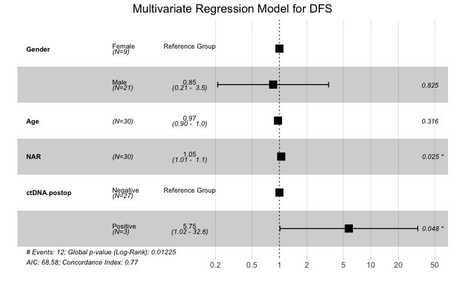

```r
rm(list=ls())
setwd("~/Downloads")
circ_data <- read.csv("Rectal IRST_Clinical Data.csv")
circ_datadf <- as.data.frame(circ_data)

circ_datadf$Gender <- factor(circ_datadf$Gender, levels = c("Female", "Male"), labels = c("Female", "Male"))
circ_datadf$ctDNA.postop <- factor(circ_datadf$ctDNA.postop, levels=c("NEGATIVE","POSITIVE"), labels = c("Negative", "Positive"))
surv_object<-Surv(time = circ_datadf$DFS.months, event = circ_datadf$DFS.Event)
cox_fit <- coxph(surv_object ~ Gender + Age + NAR + ctDNA.postop, data=circ_datadf)
ggforest(cox_fit, data = circ_datadf, main = "Multivariate Regression Model for DFS", refLabel = "Reference Group")
```

```r
test.ph <- cox.zph(cox_fit)
```

```r
rm(list=ls())
setwd("~/Downloads")
circ_data <- read.csv("Rectal IRST_Clinical Data.csv")

circ_data$ctDNA.pCR <- NA
circ_data <- circ_data %>%
  mutate(ctDNA.pCR = case_when(
    ctDNA.postNAC == "NEGATIVE" & pCR == "TRUE" ~ "1",
    ctDNA.postNAC == "NEGATIVE" & pCR == "FALSE" ~ "2",
    ctDNA.postNAC == "POSITIVE" & pCR == "FALSE" ~ "3",
  ))

survfit(Surv(time = circ_data$RFS.months, event = circ_data$RFS.Event)~ctDNA.pCR, data = circ_data)
```

```
Call: survfit(formula = Surv(time = circ_data$RFS.months, event = circ_data$RFS.Event) ~
    ctDNA.pCR, data = circ_data)

             n events median 0.95LCL 0.95UCL
ctDNA.pCR=1  6      0     NA      NA      NA
ctDNA.pCR=2 19      3     NA      NA      NA
ctDNA.pCR=3  5      5   13.2    12.2      NA
```

```r
circ_data <- circ_data[!is.na(circ_data$ctDNA.pCR),]
circ_data$ctDNA.pCR <- factor(circ_data$ctDNA.pCR, levels=c("1","2", "3"), labels=c("pCR ctDNA (-)","No pCR ctDNA (-)", "No pCR ctDNA (+)"))
survfit(Surv(time = circ_data$RFS.months, event = circ_data$RFS.Event)~ctDNA.pCR, data = circ_data)
```

```
Call: survfit(formula = Surv(time = circ_data$RFS.months, event = circ_data$RFS.Event) ~
    ctDNA.pCR, data = circ_data)

                            n events median 0.95LCL 0.95UCL
ctDNA.pCR=pCR ctDNA (-)     6      0     NA      NA      NA
ctDNA.pCR=No pCR ctDNA (-) 19      3     NA      NA      NA
ctDNA.pCR=No pCR ctDNA (+)  5      5   13.2    12.2      NA
```

```r
surv_object <-Surv(time = circ_data$RFS.months, event = circ_data$RFS.Event)
KM_curve <- survfit(surv_object ~ ctDNA.pCR, data = circ_data,conf.int=0.95,conf.type="log-log")
summary(KM_curve, times= c(36))
```

```
Call: survfit(formula = surv_object ~ ctDNA.pCR, data = circ_data,
    conf.int = 0.95, conf.type = "log-log")

                ctDNA.pCR=pCR ctDNA (-)
        time       n.risk      n.event     survival      std.err lower 95% CI upper 95% CI
          36            5            0            1            0           NA           NA

                ctDNA.pCR=No pCR ctDNA (-)
        time       n.risk      n.event     survival      std.err lower 95% CI upper 95% CI
     36.0000      15.0000       2.0000       0.8947       0.0704       0.6408       0.9726

                ctDNA.pCR=No pCR ctDNA (+)
        time       n.risk      n.event     survival      std.err lower 95% CI upper 95% CI
    36.00000      1.00000      4.00000      0.20000      0.17889      0.00837      0.58185
```

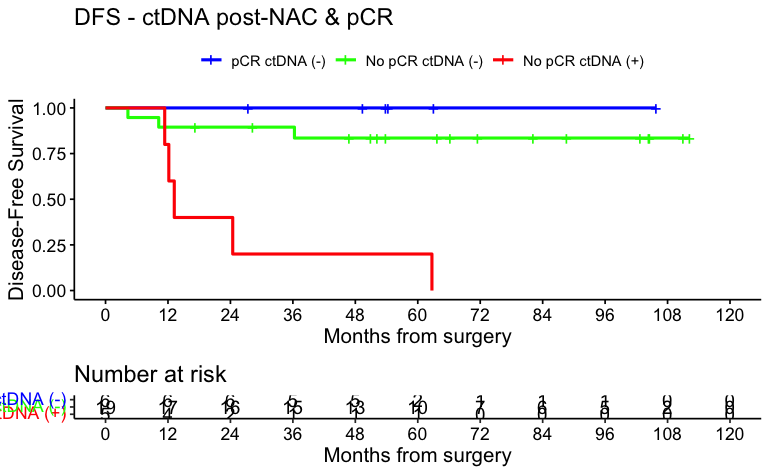

```r
ggsurvplot(KM_curve, data = circ_data, pval = FALSE, conf.int = FALSE, risk.table = TRUE, break.time.by=12, palette=c("blue", "green", "red"), title="DFS - ctDNA post-NAC & pCR", ylab= "Disease-Free Survival", xlab="Months from surgery", legend.labs=c("pCR ctDNA (-)","No pCR ctDNA (-)", "No pCR ctDNA (+)"), legend.title="")
```

```r
rm(list=ls())
setwd("~/Downloads")
circ_data <- read.csv("Rectal IRST_Clinical Data.csv")

circ_data$ctDNA.pCR <- NA
circ_data <- circ_data %>%
  mutate(ctDNA.pCR = case_when(
    ctDNA.postNAC == "NEGATIVE" & pCR == "TRUE" ~ "1",
    ctDNA.postNAC == "NEGATIVE" & pCR == "FALSE" ~ "2",
    ctDNA.postNAC == "POSITIVE" & pCR == "FALSE" ~ "3"
  ))
circ_data$ctDNA.pCR <- factor(circ_data$ctDNA.pCR, levels=c("1","2","3"))
surv_object <-Surv(time = circ_data$RFS.months, event = circ_data$RFS.Event)
cox_fit <- coxphf(surv_object ~ ctDNA.pCR, data=circ_data)
summary(cox_fit)
```

```
coxphf(formula = surv_object ~ ctDNA.pCR, data = circ_data)

Model fitted by Penalized ML
Confidence intervals and p-values by Profile Likelihood

                coef se(coef) exp(coef) lower 0.95 upper 0.95     Chisq           p
ctDNA.pCR2 0.8115447 1.653795  2.251383  0.2171987   303.1025 0.3498855 0.554177937
ctDNA.pCR3 3.0528823 1.623237 21.176292  2.3228317  2803.8027 8.4378266 0.003674952

Likelihood ratio test=11.84993 on 2 df, p=0.002671899, n=30
Wald test = 10.29557 on 2 df, p = 0.005812257

Covariance-Matrix:
           ctDNA.pCR2 ctDNA.pCR3
ctDNA.pCR2   2.735037   2.390062
ctDNA.pCR3   2.390062   2.634899
```

```r
rm(list=ls())
setwd("~/Downloads")
circ_data <- read.csv("Rectal IRST_Clinical Data.csv")
circ_data <- circ_data[circ_data$ctDNA.MRD!="",]
circ_data$DFS.months=circ_data$DFS.months-3
circ_data <- circ_data[circ_data$DFS.months>=0,]

circ_data$ctDNA.pCR <- NA
circ_data <- circ_data %>%
  mutate(ctDNA.pCR = case_when(
    ctDNA.MRD == "NEGATIVE" & pCR == "TRUE" ~ "1",
    ctDNA.MRD == "NEGATIVE" & pCR == "FALSE" ~ "2",
    ctDNA.MRD == "POSITIVE" & pCR == "FALSE" ~ "3",
  ))

survfit(Surv(time = circ_data$RFS.months, event = circ_data$RFS.Event)~ctDNA.pCR, data = circ_data)
```

```
Call: survfit(formula = Surv(time = circ_data$RFS.months, event = circ_data$RFS.Event) ~
    ctDNA.pCR, data = circ_data)

             n events median 0.95LCL 0.95UCL
ctDNA.pCR=1  5      0     NA      NA      NA
ctDNA.pCR=2 17      4     NA      NA      NA
ctDNA.pCR=3  3      3   11.4     4.3      NA
```

```r
circ_data <- circ_data[!is.na(circ_data$ctDNA.pCR),]
circ_data$ctDNA.pCR <- factor(circ_data$ctDNA.pCR, levels=c("1","2", "3"), labels=c("pCR ctDNA (-)","No pCR ctDNA (-)", "No pCR ctDNA (+)"))
survfit(Surv(time = circ_data$RFS.months, event = circ_data$RFS.Event)~ctDNA.pCR, data = circ_data)
```

```
Call: survfit(formula = Surv(time = circ_data$RFS.months, event = circ_data$RFS.Event) ~
    ctDNA.pCR, data = circ_data)

                            n events median 0.95LCL 0.95UCL
ctDNA.pCR=pCR ctDNA (-)     5      0     NA      NA      NA
ctDNA.pCR=No pCR ctDNA (-) 17      4     NA      NA      NA
ctDNA.pCR=No pCR ctDNA (+)  3      3   11.4     4.3      NA
```

```r
surv_object <-Surv(time = circ_data$RFS.months, event = circ_data$RFS.Event)
KM_curve <- survfit(surv_object ~ ctDNA.pCR, data = circ_data,conf.int=0.95,conf.type="log-log")
summary(KM_curve, times= c(24))
```

```
Call: survfit(formula = surv_object ~ ctDNA.pCR, data = circ_data,
    conf.int = 0.95, conf.type = "log-log")

                ctDNA.pCR=pCR ctDNA (-)
        time       n.risk      n.event     survival      std.err lower 95% CI upper 95% CI
          24            5            0            1            0            1            1

                ctDNA.pCR=No pCR ctDNA (-)
        time       n.risk      n.event     survival      std.err lower 95% CI upper 95% CI
     24.0000      15.0000       2.0000       0.8824       0.0781       0.6060       0.9692

                ctDNA.pCR=No pCR ctDNA (+)
        time       n.risk      n.event     survival      std.err lower 95% CI upper 95% CI
    24.00000      1.00000      2.00000      0.33333      0.27217      0.00896      0.77415
```

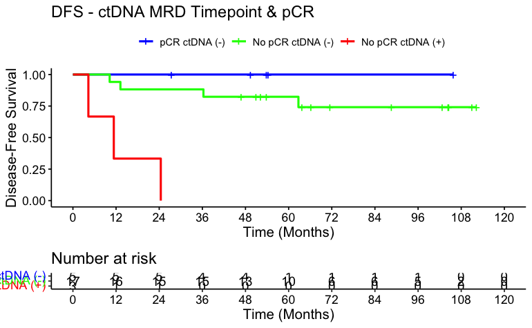

```r
ggsurvplot(KM_curve, data = circ_data, pval = FALSE, conf.int = FALSE, risk.table = TRUE, break.time.by=12, palette=c("blue", "green", "red"), title="DFS - ctDNA MRD Timepoint & pCR", ylab= "Disease-Free Survival", xlab="Time (Months)", legend.labs=c("pCR ctDNA (-)","No pCR ctDNA (-)", "No pCR ctDNA (+)"), legend.title="")
```

```r
rm(list=ls())
setwd("~/Downloads")
circ_data <- read.csv("Rectal IRST_Clinical Data.csv")
circ_data <- circ_data[circ_data$ctDNA.MRD!="",]
circ_data$DFS.months=circ_data$DFS.months-3
circ_data <- circ_data[circ_data$DFS.months>=0,]

circ_data$ctDNA.pCR <- NA
circ_data <- circ_data %>%
  mutate(ctDNA.pCR = case_when(
    ctDNA.MRD == "NEGATIVE" & pCR == "TRUE" ~ "1",
    ctDNA.MRD == "NEGATIVE" & pCR == "FALSE" ~ "2",
    ctDNA.MRD == "POSITIVE" & pCR == "FALSE" ~ "3"
  ))
circ_data$ctDNA.pCR <- factor(circ_data$ctDNA.pCR, levels=c("1","2","3"))
surv_object <-Surv(time = circ_data$RFS.months, event = circ_data$RFS.Event)
cox_fit <- coxphf(surv_object ~ ctDNA.pCR, data=circ_data)
summary(cox_fit)
```

```
coxphf(formula = surv_object ~ ctDNA.pCR, data = circ_data)

Model fitted by Penalized ML
Confidence intervals and p-values by Profile Likelihood

               coef se(coef) exp(coef) lower 0.95 upper 0.95     Chisq           p
ctDNA.pCR2 0.814095 1.639885  2.257132  0.2317876    301.287 0.3620868 0.547349552
ctDNA.pCR3 3.462331 1.709254 31.891234  2.7928253   4445.788 8.4316797 0.003687396

Likelihood ratio test=10.24975 on 2 df, p=0.005946952, n=25
Wald test = 9.203581 on 2 df, p = 0.01003385

Covariance-Matrix:
           ctDNA.pCR2 ctDNA.pCR3
ctDNA.pCR2   2.689222   2.364747
ctDNA.pCR3   2.364747   2.921551
```

#Univariate regression models for DFS for the factors used in the MVA

```r
rm(list=ls())
setwd("~/Downloads")
circ_data <- read.csv("Rectal IRST_Clinical Data.csv")
circ_datadf <- as.data.frame(circ_data)
surv_object <-Surv(time = circ_data$DFS.months, event = circ_data$DFS.Event)
circ_datadf$Gender <- factor(circ_datadf$Gender, levels = c("Female", "Male"), labels = c("Female", "Male")) #univariate for gender
cox_fit <- coxph(surv_object ~ Gender, data=circ_data)
summary(cox_fit)
```

```
Call:
coxph(formula = surv_object ~ Gender, data = circ_data)

  n= 30, number of events= 12

             coef exp(coef) se(coef)     z Pr(>|z|)
GenderMale 0.2140    1.2386   0.6675 0.321    0.749

           exp(coef) exp(-coef) lower .95 upper .95
GenderMale     1.239     0.8074    0.3348     4.583

Concordance= 0.506  (se = 0.073 )
Likelihood ratio test= 0.11  on 1 df,   p=0.7
Wald test            = 0.1  on 1 df,   p=0.7
Score (logrank) test = 0.1  on 1 df,   p=0.7
```

```r
cox_fit_summary <- summary(cox_fit)
HR <- cox_fit_summary$coefficients[2]
lower_CI <- cox_fit_summary$conf.int[3]
upper_CI <- cox_fit_summary$conf.int[4]
p_value <- cox_fit_summary$coefficients[5]
label_text <- paste0("HR = ", round(HR, 2), " (", round(lower_CI, 2), "-", round(upper_CI, 2), "); p = ", round(p_value, 3))
print(label_text)
```

```
[1] "HR = 1.24 (0.33-4.58); p = 0.749"
```

```r
rm(list=ls())
setwd("~/Downloads")
circ_data <- read.csv("Rectal IRST_Clinical Data.csv")
circ_datadf <- as.data.frame(circ_data)
surv_object <-Surv(time = circ_data$DFS.months, event = circ_data$DFS.Event)
cox_fit <- coxph(surv_object ~ Age, data=circ_data) #univariate for age
summary(cox_fit)
```

```
Call:
coxph(formula = surv_object ~ Age, data = circ_data)

  n= 30, number of events= 12

       coef exp(coef) se(coef)     z Pr(>|z|)
Age 0.01041   1.01047  0.03617 0.288    0.773

    exp(coef) exp(-coef) lower .95 upper .95
Age      1.01     0.9896    0.9413     1.085

Concordance= 0.575  (se = 0.115 )
Likelihood ratio test= 0.08  on 1 df,   p=0.8
Wald test            = 0.08  on 1 df,   p=0.8
Score (logrank) test = 0.08  on 1 df,   p=0.8
```

```r
cox_fit_summary <- summary(cox_fit)
HR <- cox_fit_summary$coefficients[2]
lower_CI <- cox_fit_summary$conf.int[3]
upper_CI <- cox_fit_summary$conf.int[4]
p_value <- cox_fit_summary$coefficients[5]
label_text <- paste0("HR = ", round(HR, 2), " (", round(lower_CI, 2), "-", round(upper_CI, 2), "); p = ", round(p_value, 3))
print(label_text)
```

```
[1] "HR = 1.01 (0.94-1.08); p = 0.773"
```

```r
rm(list=ls())
setwd("~/Downloads")
circ_data <- read.csv("Rectal IRST_Clinical Data.csv")
circ_datadf <- as.data.frame(circ_data)
surv_object <-Surv(time = circ_data$DFS.months, event = circ_data$DFS.Event)
cox_fit <- coxph(surv_object ~ NAR, data=circ_data) #univariate for NAR
summary(cox_fit)
```

```
Call:
coxph(formula = surv_object ~ NAR, data = circ_data)

  n= 30, number of events= 12

       coef exp(coef) se(coef)    z Pr(>|z|)
NAR 0.05036   1.05165  0.01579 3.19  0.00142 **
---
Signif. codes:  0 ‘***’ 0.001 ‘**’ 0.01 ‘*’ 0.05 ‘.’ 0.1 ‘ ’ 1

    exp(coef) exp(-coef) lower .95 upper .95
NAR     1.052     0.9509      1.02     1.085

Concordance= 0.788  (se = 0.051 )
Likelihood ratio test= 8.99  on 1 df,   p=0.003
Wald test            = 10.18  on 1 df,   p=0.001
Score (logrank) test = 12.41  on 1 df,   p=4e-04
```

```r
cox_fit_summary <- summary(cox_fit)
HR <- cox_fit_summary$coefficients[2]
lower_CI <- cox_fit_summary$conf.int[3]
upper_CI <- cox_fit_summary$conf.int[4]
p_value <- cox_fit_summary$coefficients[5]
label_text <- paste0("HR = ", round(HR, 2), " (", round(lower_CI, 2), "-", round(upper_CI, 2), "); p = ", round(p_value, 3))
print(label_text)
```

```
[1] "HR = 1.05 (1.02-1.08); p = 0.001"
```

```r
rm(list=ls())
setwd("~/Downloads")
circ_data <- read.csv("Rectal IRST_Clinical Data.csv")
circ_datadf <- as.data.frame(circ_data)
surv_object <-Surv(time = circ_data$DFS.months, event = circ_data$DFS.Event)
circ_data$ctDNA.postop <- factor(circ_data$ctDNA.postop, levels=c("NEGATIVE","POSITIVE"))
cox_fit <- coxph(surv_object ~ ctDNA.postop, data=circ_data) #univariate for ctDNA post-surgery
summary(cox_fit)
```

```
Call:
coxph(formula = surv_object ~ ctDNA.postop, data = circ_data)

  n= 30, number of events= 12

                        coef exp(coef) se(coef)    z Pr(>|z|)
ctDNA.postopPOSITIVE  2.5835   13.2436   0.7781 3.32 0.000899 ***
---
Signif. codes:  0 ‘***’ 0.001 ‘**’ 0.01 ‘*’ 0.05 ‘.’ 0.1 ‘ ’ 1

                     exp(coef) exp(-coef) lower .95 upper .95
ctDNA.postopPOSITIVE     13.24    0.07551     2.882     60.85

Concordance= 0.637  (se = 0.063 )
Likelihood ratio test= 8.28  on 1 df,   p=0.004
Wald test            = 11.03  on 1 df,   p=9e-04
Score (logrank) test = 18.23  on 1 df,   p=2e-05
```